# Explore_bikeshare_data

### Explore Bike Share Data

For this project, your goal is to ask and answer three questions about the available bikeshare data from Washington, Chicago, and New York. This notebook can be submitted directly through the workspace when you are confident in your results.

You will be graded against the project [Rubric](https://review.udacity.com/#!/rubrics/2508/view) by a mentor after you have submitted. To get you started, you can use the template below, but feel free to be creative in your solutions!

```r
# Importing library
library(ggplot2)
library(lubridate)
require(tidyverse)
library(dplyr)
```

```r
ny = read.csv('new_york_city.csv')
wash = read.csv('washington.csv')
chi = read.csv('chicago.csv')
```

```r
head(ny)
```

| X | Start.Time | End.Time | Trip.Duration | Start.Station | End.Station | User.Type | Gender | Birth.Year |
| --- | --- | --- | --- | --- | --- | --- | --- | --- |
| 5688089 | 2017-06-11 14:55:05 | 2017-06-11 15:08:21 | 795 | Suffolk St & Stanton St | W Broadway & Spring St | Subscriber | Male | 1998 |
| 4096714 | 2017-05-11 15:30:11 | 2017-05-11 15:41:43 | 692 | Lexington Ave & E 63 St | 1 Ave & E 78 St | Subscriber | Male | 1981 |
| 2173887 | 2017-03-29 13:26:26 | 2017-03-29 13:48:31 | 1325 | 1 Pl & Clinton St | Henry St & Degraw St | Subscriber | Male | 1987 |
| 3945638 | 2017-05-08 19:47:18 | 2017-05-08 19:59:01 | 703 | Barrow St & Hudson St | W 20 St & 8 Ave | Subscriber | Female | 1986 |
| 6208972 | 2017-06-21 07:49:16 | 2017-06-21 07:54:46 | 329 | 1 Ave & E 44 St | E 53 St & 3 Ave | Subscriber | Male | 1992 |
| 1285652 | 2017-02-22 18:55:24 | 2017-02-22 19:12:03 | 998 | State St & Smith St | Bond St & Fulton St | Subscriber | Male | 1986 |

```r
summary(ny)
```

```
       X                         Start.Time                   End.Time
 Min.   :     47   2017-05-11 18:26:10:    3   2017-01-03 08:54:10:    2
 1st Qu.:1712425   2017-01-04 13:58:24:    2   2017-01-04 17:21:55:    2
 Median :3418634   2017-01-09 09:36:01:    2   2017-01-05 17:25:17:    2
 Mean   :3415873   2017-01-21 15:36:56:    2   2017-01-12 08:34:01:    2
 3rd Qu.:5123382   2017-01-21 17:49:59:    2   2017-01-12 09:41:54:    2
 Max.   :6816152   2017-01-21 20:08:29:    2   2017-01-12 20:34:42:    2
                   (Other)            :54757   (Other)            :54758
 Trip.Duration                     Start.Station
 Min.   :     61.0   Pershing Square North:  592
 1st Qu.:    368.0   W 21 St & 6 Ave      :  385
 Median :    610.0   Broadway & E 22 St   :  383
 Mean   :    903.6   E 17 St & Broadway   :  380
 3rd Qu.:   1051.0   West St & Chambers St:  364
 Max.   :1088634.0   W 20 St & 11 Ave     :  329
 NA's   :1           (Other)              :52337
                End.Station         User.Type        Gender        Birth.Year
 Pershing Square North:  556             :  119         : 5410   Min.   :1885
 E 17 St & Broadway   :  445   Customer  : 5558   Female:12159   1st Qu.:1970
 Broadway & E 22 St   :  427   Subscriber:49093   Male  :37201   Median :1981
 W 21 St & 6 Ave      :  365                                     Mean   :1978
 W 20 St & 11 Ave     :  344                                     3rd Qu.:1988
 W 38 St & 8 Ave      :  338                                     Max.   :2001
 (Other)              :52295                                     NA's   :5218
```

```r
head(wash)
```

| X | Start.Time | End.Time | Trip.Duration | Start.Station | End.Station | User.Type |
| --- | --- | --- | --- | --- | --- | --- |
| 1621326 | 2017-06-21 08:36:34 | 2017-06-21 08:44:43 | 489.066 | 14th & Belmont St NW | 15th & K St NW | Subscriber |
| 482740 | 2017-03-11 10:40:00 | 2017-03-11 10:46:00 | 402.549 | Yuma St & Tenley Circle NW | Connecticut Ave & Yuma St NW | Subscriber |
| 1330037 | 2017-05-30 01:02:59 | 2017-05-30 01:13:37 | 637.251 | 17th St & Massachusetts Ave NW | 5th & K St NW | Subscriber |
| 665458 | 2017-04-02 07:48:35 | 2017-04-02 08:19:03 | 1827.341 | Constitution Ave & 2nd St NW/DOL | M St & Pennsylvania Ave NW | Customer |
| 1481135 | 2017-06-10 08:36:28 | 2017-06-10 09:02:17 | 1549.427 | Henry Bacon Dr & Lincoln Memorial Circle NW | Maine Ave & 7th St SW | Subscriber |
| 1148202 | 2017-05-14 07:18:18 | 2017-05-14 07:24:56 | 398.000 | 1st & K St SE | Eastern Market Metro / Pennsylvania Ave & 7th St SE | Subscriber |

```r
summary(wash)
```

```
       X                         Start.Time                   End.Time
 Min.   :      7   2017-02-19 12:19:00:    6   2017-03-09 17:54:00:    7
 1st Qu.: 434587   2017-02-20 11:35:00:    6   2017-03-28 18:11:00:    7
 Median : 872858   2017-02-24 17:46:00:    6   2017-01-13 17:48:00:    6
 Mean   : 873881   2017-03-01 08:20:00:    6   2017-01-31 08:49:00:    6
 3rd Qu.:1313305   2017-03-02 08:39:00:    6   2017-02-13 18:09:00:    6
 Max.   :1751392   2017-03-09 17:31:00:    6   2017-02-20 11:38:00:    6
                   (Other)            :89015   (Other)            :89013
 Trip.Duration                                   Start.Station
 Min.   :    60.3   Columbus Circle / Union Station     : 1700
 1st Qu.:   410.9   Lincoln Memorial                    : 1546
 Median :   707.0   Jefferson Dr & 14th St SW           : 1488
 Mean   :  1234.0   Massachusetts Ave & Dupont Circle NW: 1219
 3rd Qu.:  1233.2   Jefferson Memorial                  : 1068
 Max.   :904591.4   15th & P St NW                      : 1040
 NA's   :1          (Other)                             :80990
                                                End.Station
 Columbus Circle / Union Station                      : 1767
 Jefferson Dr & 14th St SW                            : 1603
 Lincoln Memorial                                     : 1514
 Massachusetts Ave & Dupont Circle NW                 : 1344
 Smithsonian-National Mall / Jefferson Dr & 12th St SW: 1103
 15th & P St NW                                       : 1077
 (Other)                                              :80643
      User.Type
           :    1
 Customer  :23450
 Subscriber:65600
```

```r
head(chi)
```

| X | Start.Time | End.Time | Trip.Duration | Start.Station | End.Station | User.Type | Gender | Birth.Year |
| --- | --- | --- | --- | --- | --- | --- | --- | --- |
| 1423854 | 2017-06-23 15:09:32 | 2017-06-23 15:14:53 | 321 | Wood St & Hubbard St | Damen Ave & Chicago Ave | Subscriber | Male | 1992 |
| 955915 | 2017-05-25 18:19:03 | 2017-05-25 18:45:53 | 1610 | Theater on the Lake | Sheffield Ave & Waveland Ave | Subscriber | Female | 1992 |
| 9031 | 2017-01-04 08:27:49 | 2017-01-04 08:34:45 | 416 | May St & Taylor St | Wood St & Taylor St | Subscriber | Male | 1981 |
| 304487 | 2017-03-06 13:49:38 | 2017-03-06 13:55:28 | 350 | Christiana Ave & Lawrence Ave | St. Louis Ave & Balmoral Ave | Subscriber | Male | 1986 |
| 45207 | 2017-01-17 14:53:07 | 2017-01-17 15:02:01 | 534 | Clark St & Randolph St | Desplaines St & Jackson Blvd | Subscriber | Male | 1975 |
| 1473887 | 2017-06-26 09:01:20 | 2017-06-26 09:11:06 | 586 | Clinton St & Washington Blvd | Canal St & Taylor St | Subscriber | Male | 1990 |

```r
summary(chi)
```

```
       X                         Start.Time                  End.Time
 Min.   :     36   2017-01-24 07:40:32:   2   2017-04-16 13:16:52:   2
 1st Qu.: 386722   2017-04-22 13:16:25:   2   2017-04-26 16:29:26:   2
 Median : 773554   2017-05-27 15:17:50:   2   2017-05-21 16:20:56:   2
 Mean   : 776721   2017-06-10 13:29:41:   2   2017-05-27 09:58:21:   2
 3rd Qu.:1171266   2017-06-20 17:05:11:   2   2017-06-25 14:51:35:   2
 Max.   :1551248   2017-06-21 13:18:52:   2   2017-01-01 00:46:32:   1
                   (Other)            :8618   (Other)            :8619
 Trip.Duration                          Start.Station
 Min.   :   60.0   Streeter Dr & Grand Ave     : 210
 1st Qu.:  394.2   Lake Shore Dr & Monroe St   : 140
 Median :  670.0   Clinton St & Washington Blvd: 120
 Mean   :  937.2   Clinton St & Madison St     : 102
 3rd Qu.: 1119.0   Canal St & Adams St         : 101
 Max.   :85408.0   Michigan Ave & Oak St       :  98
                   (Other)                     :7859
                       End.Station        User.Type       Gender
 Streeter Dr & Grand Ave     : 233             :   1         :1748
 Clinton St & Madison St     : 145   Customer  :1746   Female:1723
 Theater on the Lake         : 131   Subscriber:6883   Male  :5159
 Lake Shore Dr & Monroe St   : 115
 Clinton St & Washington Blvd: 109
 Lake Shore Dr & North Blvd  : 102
 (Other)                     :7795
   Birth.Year
 Min.   :1899
 1st Qu.:1975
 Median :1984
 Mean   :1981
 3rd Qu.:1989
 Max.   :2002
 NA's   :1747
```

```r
#creating city columns for ny and chi files
ny$City = 'nyc'
chi$City = 'chi'
wash$City = 'wash'
```

```r
colnames(ny)
```

1. 'X'

2. 'Start.Time'

3. 'End.Time'

4. 'Trip.Duration'

5. 'Start.Station'

6. 'End.Station'

7. 'User.Type'

8. 'Gender'

9. 'Birth.Year'

10. 'City'

```r
colnames(wash)
```

1. 'X'

2. 'Start.Time'

3. 'End.Time'

4. 'Trip.Duration'

5. 'Start.Station'

6. 'End.Station'

7. 'User.Type'

8. 'City'

```r
colnames(chi)
```

1. 'X'

2. 'Start.Time'

3. 'End.Time'

4. 'Trip.Duration'

5. 'Start.Station'

6. 'End.Station'

7. 'User.Type'

8. 'Gender'

9. 'Birth.Year'

10. 'City'

### Question 1

> What is the most common start station in each city?

> Is this start station the same every day of the week?

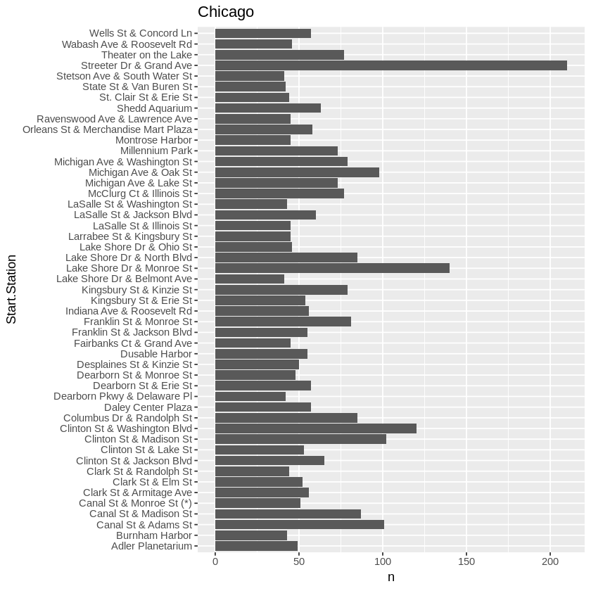

```r
#Checking the most commonly used start station for Chicago
#Referenced: https://ggplot2.tidyverse.org/reference/coord_flip.html#:~:text=coord_flip.Rd,to%20x%20conditional%20on%20y.
#and https://www.geeksforgeeks.org/data-visualization-with-r-and-ggplot2/
start_stations_c <- chi %>%
  group_by(Start.Station) %>%
  summarise(n = n()) %>%
  filter(n > 40)


 ggplot(start_stations_c, aes(Start.Station, n))+
  geom_col()+
  labs(title = 'Chicago')+
    coord_flip()
```

```r
# Sort descending order and show the top five
start_stations_c <- start_stations_c %>% arrange(desc(n))
head(start_stations_c, 5)
```

| Start.Station | n |
| --- | --- |
| Streeter Dr & Grand Ave | 210 |
| Lake Shore Dr & Monroe St | 140 |
| Clinton St & Washington Blvd | 120 |
| Clinton St & Madison St | 102 |
| Canal St & Adams St | 101 |

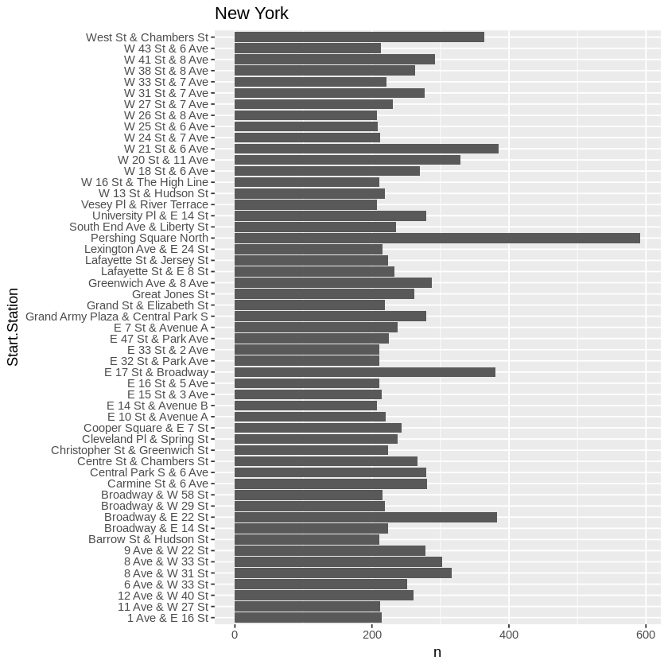

```r
#Checking the most commonly used start station for New York
start_stations_n <- ny %>%
  group_by(Start.Station) %>%
  summarise(n = n()) %>%
  filter(n > 200)

ggplot(start_stations_n, aes(Start.Station, n))+
  geom_col()+
  labs(title = 'New York')+
    coord_flip()
```

```r
# Sort descending order and show the top five
start_stations_n <- start_stations_n %>% arrange(desc(n))
head(start_stations_n, 5)
```

| Start.Station | n |
| --- | --- |
| Pershing Square North | 592 |
| W 21 St & 6 Ave | 385 |
| Broadway & E 22 St | 383 |
| E 17 St & Broadway | 380 |
| West St & Chambers St | 364 |

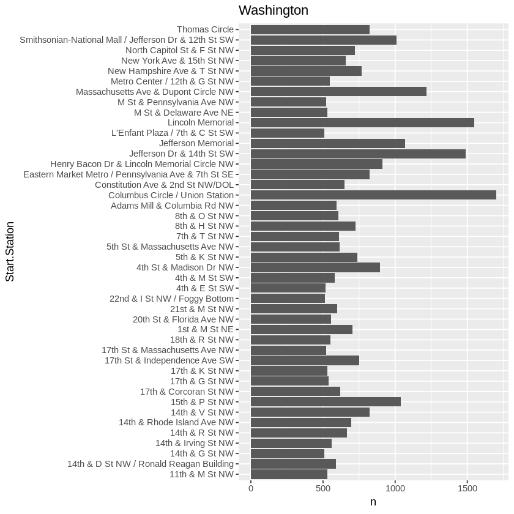

```r
#Referenced: https://www.geeksforgeeks.org/group-by-function-in-r-using-dplyr/
#Checking the most commonly used start station for Washington

start_stations_w <- wash %>%
  group_by(Start.Station) %>%
  summarise(n = n()) %>%
  filter(n > 500)

ggplot(start_stations_w, aes(Start.Station, n))+
  geom_col()+
  labs(title = 'Washington')+
  coord_flip()
```

```r
# Sort descending order
start_stations_w <- start_stations_w %>% arrange(desc(n))
head(start_stations_w, 5)
```

| Start.Station | n |
| --- | --- |
| Columbus Circle / Union Station | 1700 |
| Lincoln Memorial | 1546 |
| Jefferson Dr & 14th St SW | 1488 |
| Massachusetts Ave & Dupont Circle NW | 1219 |
| Jefferson Memorial | 1068 |

```r
#Reducing the dataframes to work with them better
chi_ss <- chi[c("X", "City", "Start.Station")]
wash_ss <- wash[c("X", "City", "Start.Station")]
ny_ss <- ny[c("X", "City", "Start.Station")]

# Merge the selected columns into a single dataframe
ss_merged_df <- rbind(chi_ss, wash_ss, ny_ss)
head(ss_merged_df, 10)
```

| X | City | Start.Station |
| --- | --- | --- |
| 1423854 | chi | Wood St & Hubbard St |
| 955915 | chi | Theater on the Lake |
| 9031 | chi | May St & Taylor St |
| 304487 | chi | Christiana Ave & Lawrence Ave |
| 45207 | chi | Clark St & Randolph St |
| 1473887 | chi | Clinton St & Washington Blvd |
| 961916 | chi | Ashland Ave & Lake St |
| 65924 | chi | Larrabee St & Kingsbury St |
| 606841 | chi | Sedgwick St & Huron St |
| 135470 | chi | Stetson Ave & South Water St |

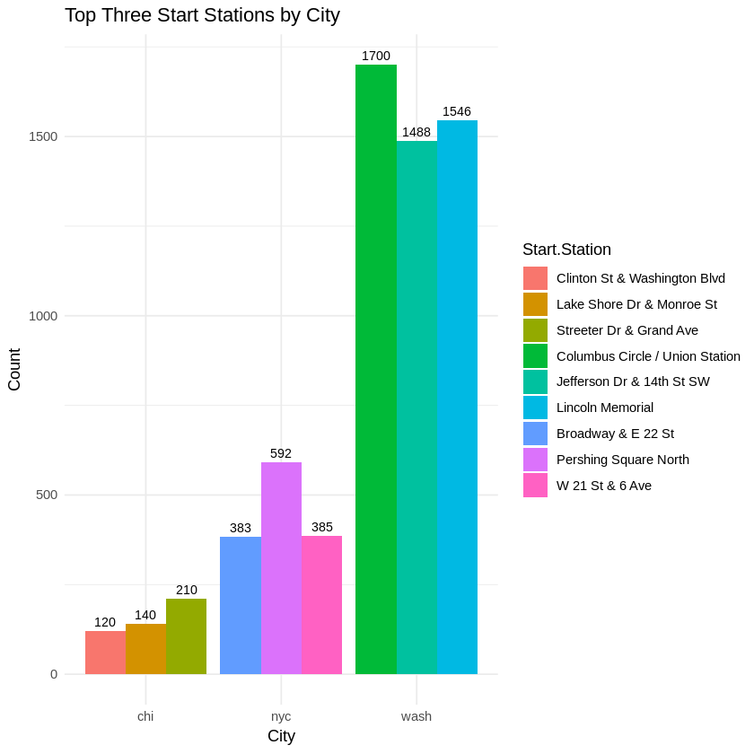

```r
#referenced: https://stackoverflow.com/questions/12018499/how-to-put-labels-over-geom-bar-for-each-bar-in-r-with-ggplot2

# Calculate the counts of start stations by city
start_stations_counts <- ss_merged_df %>%
  group_by(City, Start.Station) %>%
  summarise(Count = n()) %>%
  filter(!is.na(Start.Station) & Start.Station != "") %>%
  arrange(City, desc(Count))


# Select the top three start stations for each city
top_start_stations <- start_stations_counts %>%
  group_by(City) %>%
  top_n(n = 3, wt = Count)

# using ggplot to chart the top three start stations in each city
ggplot(top_start_stations, aes(x = City, y = Count, fill = Start.Station)) +
  geom_bar(stat = "identity", position = "dodge") +
  geom_text(aes(label = Count), position = position_dodge(width = 0.9), vjust = -0.5, color = "black", size = 3) +
  labs(title = "Top Three Start Stations by City",
       x = "City",
       y = "Count") +
  theme_minimal()
```

###### Results

The most often used starting station in each city is:

> Chicago - Streeter Dr. & Grand Ave

> New York - Pershing Square North

> Washington - Columbus Circle/Union Station

```r
#referenced: https://argoshare.is.ed.ac.uk/healthyr_book/missing-values-nas-and-filters.html
# In order to find out if the most popular start station remains popular throughout the week, we need get the day of the week
chi <- chi %>%
  mutate(Start.Day = format(as.Date(Start.Time), "%A"))

wash <- wash %>%
  mutate(Start.Day = format(as.Date(Start.Time), "%A"))

ny <- ny %>%
  mutate(Start.Day = format(as.Date(Start.Time), "%A"))

# Find the most often used Start Station for each day of the week in each dataframe
chi_most_often <- chi %>%
  group_by(Start.Day, Start.Station) %>%
  tally() %>%
  group_by(Start.Day) %>%
  top_n(1, wt = n)

wash_most_often <- wash %>%
  group_by(Start.Day, Start.Station) %>%
  tally() %>%
  group_by(Start.Day) %>%
  filter(!is.na(Start.Station) & Start.Station != "") %>%
  top_n(1, wt = n)


ny_most_often <- ny %>%
  group_by(Start.Day, Start.Station) %>%
  tally() %>%
  group_by(Start.Day) %>%
  top_n(1, wt = n)

# Print the results
chi_most_often
wash_most_often
ny_most_often
```

| Start.Day | Start.Station | n |
| --- | --- | --- |
| Friday | Clinton St & Washington Blvd | 27 |
| Friday | Streeter Dr & Grand Ave | 27 |
| Monday | Clinton St & Washington Blvd | 26 |
| Saturday | Streeter Dr & Grand Ave | 56 |
| Sunday | Streeter Dr & Grand Ave | 44 |
| Thursday | Streeter Dr & Grand Ave | 21 |
| Tuesday | Clinton St & Washington Blvd | 24 |
| Wednesday | Canal St & Adams St | 25 |

| Start.Day | Start.Station | n |
| --- | --- | --- |
| Friday | Columbus Circle / Union Station | 260 |
| Monday | Columbus Circle / Union Station | 240 |
| Saturday | Lincoln Memorial | 331 |
| Sunday | Lincoln Memorial | 324 |
| Thursday | Columbus Circle / Union Station | 333 |
| Tuesday | Columbus Circle / Union Station | 320 |
| Wednesday | Columbus Circle / Union Station | 346 |

| Start.Day | Start.Station | n |
| --- | --- | --- |
| Friday | Pershing Square North | 103 |
| Monday | Pershing Square North | 101 |
| Saturday | W 21 St & 6 Ave | 45 |
| Sunday | West St & Chambers St | 57 |
| Thursday | Pershing Square North | 114 |
| Tuesday | Pershing Square North | 110 |
| Wednesday | Pershing Square North | 111 |

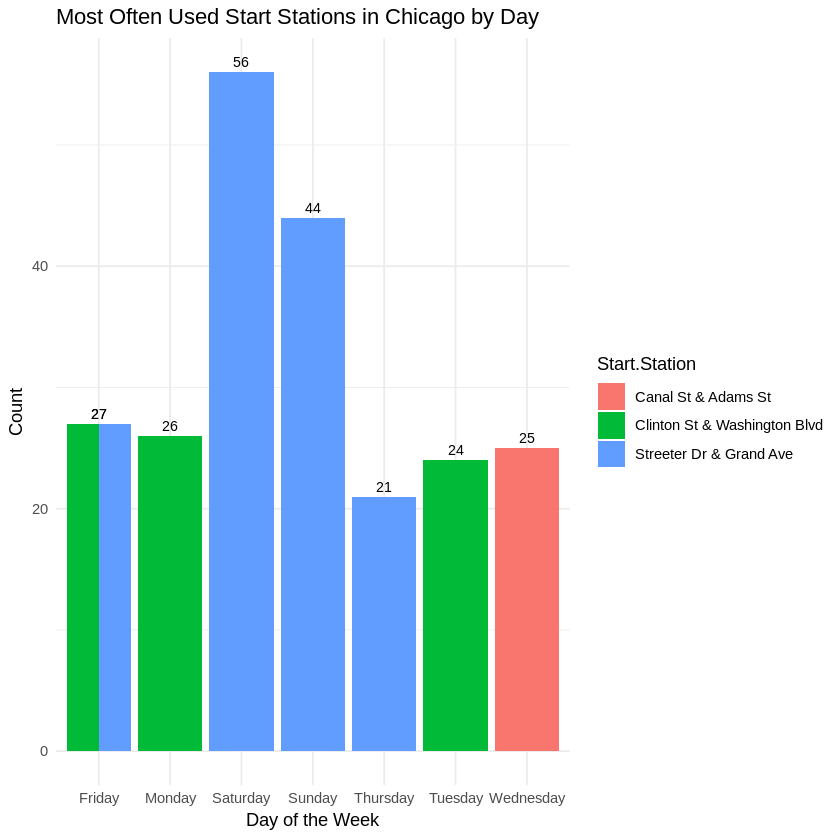

```r
# Create the bar chart to display most often used start station by day of the week
bar_chart_chi <- ggplot(chi_most_often, aes(x = Start.Day, y = n, fill = Start.Station)) +
  geom_bar(stat = "identity", position = "dodge") +
  geom_text(aes(label = n), vjust = -0.5, color = "black", size = 3) +
  labs(title = "Most Often Used Start Stations in Chicago by Day",
       x = "Day of the Week",
       y = "Count") +
  theme_minimal()

print(bar_chart_chi)
```

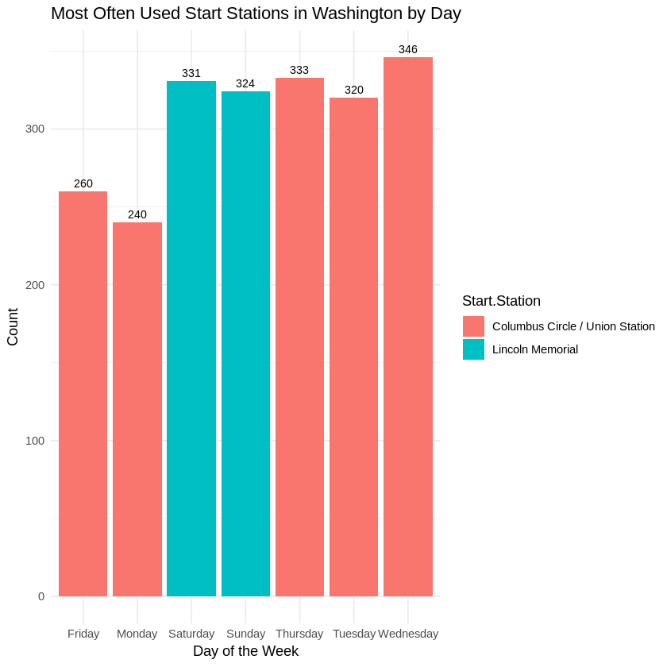

```r
# Create the bar chart to display most often used start station by day of the week
bar_chart_wash <- ggplot(wash_most_often, aes(x = Start.Day, y = n, fill = Start.Station)) +
  geom_bar(stat = "identity", position = "dodge") +
  geom_text(aes(label = n), vjust = -0.5, color = "black", size = 3) +
  labs(title = "Most Often Used Start Stations in Washington by Day",
       x = "Day of the Week",
       y = "Count") +
  theme_minimal()

print(bar_chart_wash)
```

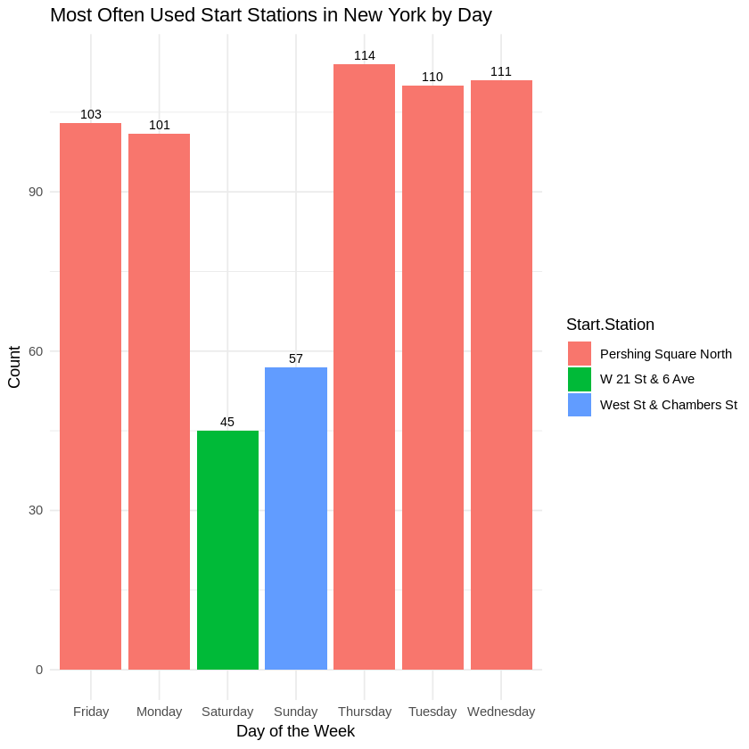

```r
# Create the bar chart to display most often used start station by day of the week
bar_chart_ny <- ggplot(ny_most_often, aes(x = Start.Day, y = n, fill = Start.Station)) +
  geom_bar(stat = "identity", position = "dodge") +
  geom_text(aes(label = n), vjust = -0.5, color = "black", size = 3) +
  labs(title = "Most Often Used Start Stations in New York by Day",
       x = "Day of the Week",
       y = "Count") +
  theme_minimal()

print(bar_chart_ny)
```

### Question 1 Results

##### Most common start station in each city:

###### Chicago

> Streeter Dr. and Grand Avenue

###### New York

> Pershing Square North

###### Washington

> Columbus Circle/Union Station

##### Does this remain constant throughout the week?

###### Chicago

> Most days of the week, riders start at Streeter Dr. and Grand Ave. Riders start here most often on Thursday, Saturday and Sunday, and this start station tied with Clinton St. and Washington Blvd on Fridays.

###### New York

> Pershing Square North has the most riders 5 days out of the week. These days are weekdays, with Saturday and Sunday having a much lower volume at the top spot. W 21 St. & 6th is more popular on Saturdays, and West St. & Chambers St. is on Sunday.

###### Washington

> Columbus Circle/Union Station is the most popular start station on weekdays, but Lincoln memorial is the most popular on Weekends.

### Question 2

> What is the most common age of riders in each city (excluding Washington)?

> Does this vary when considering gender?

```r
#calculating age from birth year and creating a range for the ages
calculate_age_range <- function(data) {
  data %>%
    mutate(Age = floor((as.integer(format(Sys.Date(), "%Y")) - Birth.Year) / 10) * 10) %>%
    group_by(Age) %>%
    summarise(count = n()) %>%
    filter(Age >= 10 & Age < 100) %>% #filtered out outlier ages
    arrange(desc(count))
}

# Calculate the most common age range counting by 10 for each dataframe
ny_age_range <- calculate_age_range(ny)
chi_age_range <- calculate_age_range(chi)

ny_age_range
chi_age_range
```

| Age | count |
| --- | --- |
| 30 | 18284 |
| 40 | 13030 |
| 50 | 9202 |
| 60 | 5419 |
| 20 | 2202 |
| 70 | 1261 |
| 80 | 127 |
| 90 | 6 |

| Age | count |
| --- | --- |
| 30 | 3326 |
| 40 | 1672 |
| 50 | 944 |
| 60 | 506 |
| 20 | 306 |
| 70 | 115 |
| 80 | 7 |
| 90 | 1 |

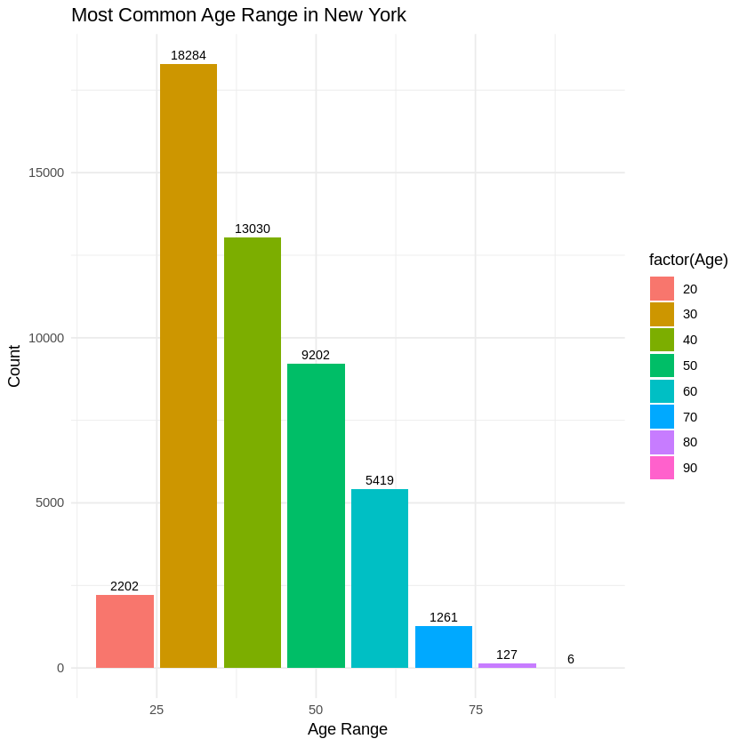

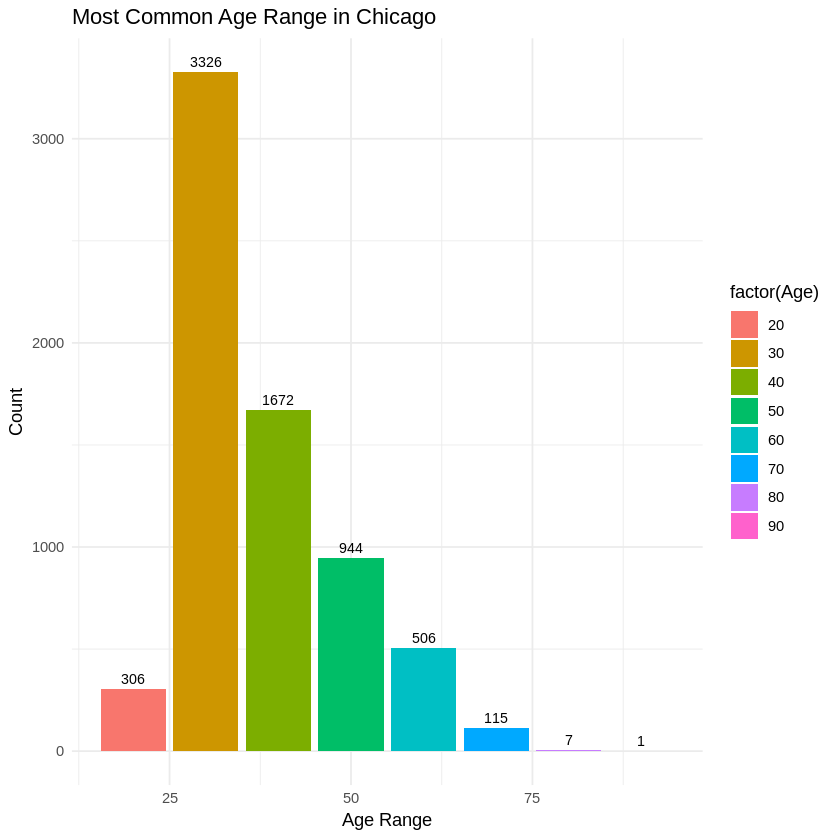

```r
create_bar_chart <- function(data, city) {
  ggplot(data, aes(x = Age, y = count, fill = factor(Age))) +
    geom_bar(stat = "identity") +
    geom_text(aes(label = count), vjust = -0.5, color = "black", size = 3) +
    labs(title = paste("Most Common Age Range in", city),
         x = "Age Range",
         y = "Count") +
    theme_minimal()
}

# Create a bar chart with data labels for ny_age_range
bar_chart_ny <- create_bar_chart(ny_age_range, "New York")

# Create a bar chart with data labels for chi_age_range
bar_chart_chi <- create_bar_chart(chi_age_range, "Chicago")

# Print the bar charts
print(bar_chart_ny)
print(bar_chart_chi)
```

```r
#referenced: https://dplyr.tidyverse.org/reference/mutate.html
#calculating age from birth year and creating a range for the ages
calculate_age_range <- function(data) {
  data %>%
    mutate(Age = floor((as.integer(format(Sys.Date(), "%Y")) - Birth.Year) / 10) * 10) %>%
    group_by(Age, Gender) %>%
    summarise(count = n()) %>%
    filter(Age >= 10 & Age < 100) %>% #filtered out outlier ages
    arrange(desc(count))
}

# Calculate the most common age range counting by 10 for each dataframe
ny_age_range <- calculate_age_range(ny)
chi_age_range <- calculate_age_range(chi)

ny_age_range
chi_age_range
```

| Age | Gender | count |
| --- | --- | --- |
| 30 | Male | 13220 |
| 40 | Male | 10099 |
| 50 | Male | 7072 |
| 30 | Female | 5012 |
| 60 | Male | 4105 |
| 40 | Female | 2861 |
| 50 | Female | 2091 |
| 20 | Male | 1577 |
| 60 | Female | 1305 |
| 70 | Male | 1005 |
| 20 | Female | 611 |
| 70 | Female | 253 |
| 80 | Male | 106 |
| 40 |  | 70 |
| 30 |  | 52 |
| 50 |  | 39 |
| 80 | Female | 19 |
| 20 |  | 14 |
| 60 |  | 9 |
| 90 | Female | 5 |
| 70 |  | 3 |
| 80 |  | 2 |
| 90 | Male | 1 |

| Age | Gender | count |
| --- | --- | --- |
| 30 | Male | 2374 |
| 40 | Male | 1300 |
| 30 | Female | 952 |
| 50 | Male | 760 |
| 60 | Male | 412 |
| 40 | Female | 371 |
| 20 | Male | 203 |
| 50 | Female | 184 |
| 20 | Female | 103 |
| 70 | Male | 96 |
| 60 | Female | 94 |
| 70 | Female | 19 |
| 80 | Male | 7 |
| 40 |  | 1 |
| 90 | Male | 1 |

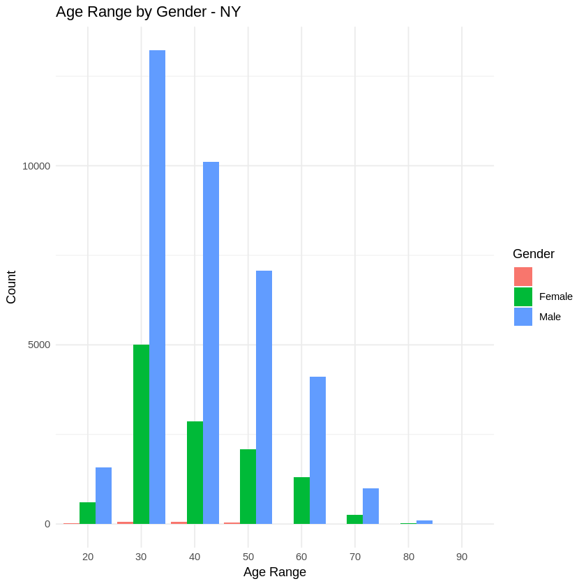

```r
#displaying age ranges by gender
ggplot(ny_age_range, aes(x = factor(Age), y = count, fill = Gender)) +
  geom_bar(stat = "identity", position = "dodge") +
  labs(title = "Age Range by Gender - NY",
       x = "Age Range",
       y = "Count",
       fill = "Gender") +
  theme_minimal()
```

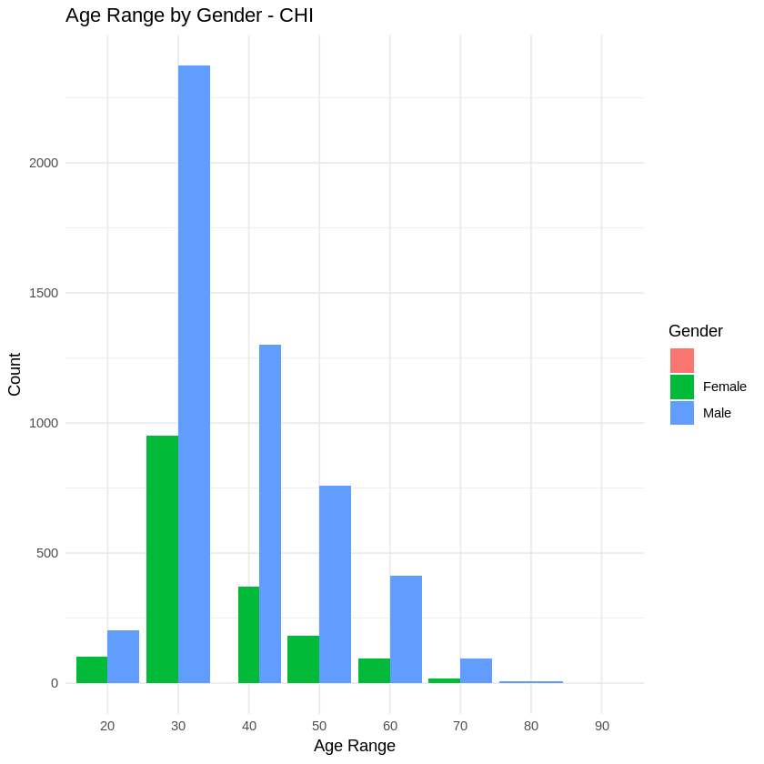

```r
# Bar chart for chi_age_range
ggplot(chi_age_range, aes(x = factor(Age), y = count, fill = Gender)) +
  geom_bar(stat = "identity", position = "dodge") +
  labs(title = "Age Range by Gender - CHI",
       x = "Age Range",
       y = "Count",
       fill = "Gender") +
  theme_minimal()
```

### Question 2 Results

###### What is the most common age range?

> The most common age range for both New York and Chicago is between 30 and 39. This is followed by people in their 40's.

###### What is the most common age range when accounting for gender?

> For both Male and female there in both cities is still in the 30's. One thing we see though is that there are significantly more male riders regardless of age range.

Note: Washington did not provide birth year and we could not calculate age range.

### Question 3

> What time of day is most common in each city?

> What is the most common end time in each city?

```r
#create new column called start.hour

create_start_hour_column <- function(data) {
  data %>%
    mutate(Start.Time = ymd_hms(Start.Time),  # Convert Start.Time to proper date/time format
           start.hour = hour(Start.Time))     # Extract hour component
}

wash <- create_start_hour_column(wash)
ny <- create_start_hour_column(ny)
chi <- create_start_hour_column(chi)

wash
```

| X | Start.Time | End.Time | Trip.Duration | Start.Station | End.Station | User.Type | City | Start.Day | start.hour |
| --- | --- | --- | --- | --- | --- | --- | --- | --- | --- |
| 1621326 | 2017-06-21 08:36:34 | 2017-06-21 08:44:43 | 489.066 | 14th & Belmont St NW | 15th & K St NW | Subscriber | wash | Wednesday | 8 |
| 482740 | 2017-03-11 10:40:00 | 2017-03-11 10:46:00 | 402.549 | Yuma St & Tenley Circle NW | Connecticut Ave & Yuma St NW | Subscriber | wash | Saturday | 10 |
| 1330037 | 2017-05-30 01:02:59 | 2017-05-30 01:13:37 | 637.251 | 17th St & Massachusetts Ave NW | 5th & K St NW | Subscriber | wash | Tuesday | 1 |
| 665458 | 2017-04-02 07:48:35 | 2017-04-02 08:19:03 | 1827.341 | Constitution Ave & 2nd St NW/DOL | M St & Pennsylvania Ave NW | Customer | wash | Sunday | 7 |
| 1481135 | 2017-06-10 08:36:28 | 2017-06-10 09:02:17 | 1549.427 | Henry Bacon Dr & Lincoln Memorial Circle NW | Maine Ave & 7th St SW | Subscriber | wash | Saturday | 8 |
| 1148202 | 2017-05-14 07:18:18 | 2017-05-14 07:24:56 | 398.000 | 1st & K St SE | Eastern Market Metro / Pennsylvania Ave & 7th St SE | Subscriber | wash | Sunday | 7 |
| 1594275 | 2017-06-19 08:41:43 | 2017-06-19 09:00:08 | 1105.429 | Park Rd & Holmead Pl NW | 8th & H St NW | Subscriber | wash | Monday | 8 |
| 1601832 | 2017-06-20 05:54:42 | 2017-06-20 06:05:18 | 636.218 | 1st & D St SE | Potomac & Pennsylvania Ave SE | Subscriber | wash | Tuesday | 5 |
| 574182 | 2017-03-24 20:37:00 | 2017-03-24 20:42:00 | 328.530 | 18th & R St NW | 15th & P St NW | Subscriber | wash | Friday | 20 |
| 327058 | 2017-02-20 21:12:00 | 2017-02-20 21:31:00 | 1188.090 | 17th & Corcoran St NW | Lynn & 19th St North | Subscriber | wash | Monday | 21 |
| 854729 | 2017-04-17 02:50:51 | 2017-04-17 03:05:17 | 866.689 | 37th & O St NW / Georgetown University | 37th & O St NW / Georgetown University | Customer | wash | Monday | 2 |
| 721887 | 2017-04-08 01:12:48 | 2017-04-08 01:52:33 | 2385.411 | 10th & G St NW | 5th St & Massachusetts Ave NW | Customer | wash | Saturday | 1 |
| 143181 | 2017-01-26 20:01:00 | 2017-01-26 20:17:00 | 951.457 | 10th St & L'Enfant Plaza SW | 1st & Rhode Island Ave NW | Subscriber | wash | Thursday | 20 |
| 26953 | 2017-01-06 17:36:00 | 2017-01-06 17:43:00 | 448.628 | North Capitol St & F St NW | 1st & M St NE | Subscriber | wash | Friday | 17 |
| 1308542 | 2017-05-28 03:50:26 | 2017-05-28 04:24:26 | 2039.472 | Henry Bacon Dr & Lincoln Memorial Circle NW | Lincoln Memorial | Customer | wash | Sunday | 3 |
| 1592744 | 2017-06-19 07:46:35 | 2017-06-19 07:55:00 | 505.482 | Metro Center / 12th & G St NW | North Capitol St & G Pl NE | Subscriber | wash | Monday | 7 |
| 1139713 | 2017-05-13 11:29:16 | 2017-05-13 11:55:47 | 1591.326 | 16th & Harvard St NW | New York Ave & 15th St NW | Customer | wash | Saturday | 11 |
| 1478516 | 2017-06-10 06:04:41 | 2017-06-10 06:32:33 | 1672.075 | 17th St & Massachusetts Ave NW | 15th & East Capitol St NE | Subscriber | wash | Saturday | 6 |
| 679837 | 2017-04-03 10:22:19 | 2017-04-03 10:26:11 | 231.952 | 20th & Crystal Dr | 6th & S Ball St | Subscriber | wash | Monday | 10 |
| 1392498 | 2017-06-03 11:42:54 | 2017-06-03 12:21:05 | 2291.454 | 22nd & I St NW / Foggy Bottom | Lamont & Mt Pleasant NW | Customer | wash | Saturday | 11 |
| 746605 | 2017-04-09 11:05:42 | 2017-04-09 11:26:44 | 1261.363 | Henry Bacon Dr & Lincoln Memorial Circle NW | Smithsonian-National Mall / Jefferson Dr & 12th St SW | Customer | wash | Sunday | 11 |
| 868881 | 2017-04-18 05:42:04 | 2017-04-18 06:31:28 | 2964.818 | Anacostia Metro | Congress Heights Metro | Subscriber | wash | Tuesday | 5 |
| 1161275 | 2017-05-15 07:35:21 | 2017-05-15 07:49:06 | 825.590 | 3rd & H St NE | Oklahoma Ave & D St NE | Subscriber | wash | Monday | 7 |
| 305000 | 2017-02-19 00:43:00 | 2017-02-19 00:46:00 | 226.006 | 18th St & Wyoming Ave NW | Calvert St & Woodley Pl NW | Subscriber | wash | Sunday | 0 |
| 1174029 | 2017-05-16 07:34:43 | 2017-05-16 07:50:04 | 920.840 | Florida Ave & R St NW | L'Enfant Plaza / 7th & C St SW | Subscriber | wash | Tuesday | 7 |
| 1157984 | 2017-05-15 05:39:22 | 2017-05-15 06:02:14 | 1371.512 | Lincoln Memorial | Arlington Blvd & Fillmore St | Subscriber | wash | Monday | 5 |
| 694527 | 2017-04-05 01:36:31 | 2017-04-05 01:40:45 | 254.076 | 13th St & New York Ave NW | 11th & M St NW | Subscriber | wash | Wednesday | 1 |
| 228536 | 2017-02-08 09:17:00 | 2017-02-08 09:31:00 | 834.780 | 39th & Calvert St NW / Stoddert | Massachusetts Ave & Dupont Circle NW | Subscriber | wash | Wednesday | 9 |
| 669432 | 2017-04-02 12:11:35 | 2017-04-02 02:15:22 | 7427.749 | 2nd St & Massachusetts Ave NE | 2nd St & Massachusetts Ave NE | Customer | wash | Sunday | 12 |
| 1036255 | 2017-05-02 11:49:43 | 2017-05-02 12:09:09 | 1165.698 | 10th & K St NW | Georgetown Harbor / 30th St NW | Subscriber | wash | Tuesday | 11 |
| ⋮ | ⋮ | ⋮ | ⋮ | ⋮ | ⋮ | ⋮ | ⋮ | ⋮ | ⋮ |
| 676408 | 2017-04-03 07:03:02 | 2017-04-03 07:16:01 | 779.371 | 10th & K St NW | 17th & Corcoran St NW | Subscriber | wash | Monday | 7 |
| 551347 | 2017-03-22 09:30:00 | 2017-03-22 09:34:00 | 275.761 | Offutt Ln & Chevy Chase Dr | Bethesda Ave & Arlington Rd | Subscriber | wash | Wednesday | 9 |
| 905153 | 2017-04-21 04:39:43 | 2017-04-21 04:47:19 | 456.235 | 3rd & G St SE | Columbus Circle / Union Station | Subscriber | wash | Friday | 4 |
| 625949 | 2017-03-29 15:39:00 | 2017-03-29 16:23:00 | 2692.475 | Columbus Circle / Union Station | Washington & Independence Ave SW/HHS | Subscriber | wash | Wednesday | 15 |
| 1667242 | 2017-06-25 02:03:23 | 2017-06-25 02:07:28 | 244.334 | 13th St & New York Ave NW | 11th & M St NW | Subscriber | wash | Sunday | 2 |
| 241483 | 2017-02-09 21:14:00 | 2017-02-09 21:22:00 | 468.211 | Braddock Rd Metro | Mount Vernon Ave & E Del Ray Ave | Subscriber | wash | Thursday | 21 |
| 893870 | 2017-04-20 05:32:02 | 2017-04-20 05:41:26 | 564.069 | 1st & O St NW | 8th & H St NW | Subscriber | wash | Thursday | 5 |
| 1673660 | 2017-06-25 07:58:00 | 2017-06-25 08:40:40 | 2560.164 | Ballston Metro / N Stuart & 9th St N | Ballston Metro / N Stuart & 9th St N | Subscriber | wash | Sunday | 7 |
| 531841 | 2017-03-20 11:44:00 | 2017-03-20 11:56:00 | 707.024 | 18th & M St NW | Metro Center / 12th & G St NW | Subscriber | wash | Monday | 11 |
| 1143611 | 2017-05-14 03:06:09 | 2017-05-14 03:39:27 | 1997.738 | 4th & C St SW | 4th & M St SW | Customer | wash | Sunday | 3 |
| 760548 | 2017-04-10 09:49:09 | 2017-04-10 10:08:06 | 1136.869 | Jefferson Dr & 14th St SW | 4th St & Madison Dr NW | Customer | wash | Monday | 9 |
| 585303 | 2017-03-25 16:15:00 | 2017-03-25 17:02:00 | 2817.361 | Jefferson Dr & 14th St SW | New York Ave & 15th St NW | Subscriber | wash | Saturday | 16 |
| 774610 | 2017-04-11 09:01:58 | 2017-04-11 09:10:36 | 518.196 | 7th & E St SW | 6th St & Indiana Ave NW | Subscriber | wash | Tuesday | 9 |
| 1681261 | 2017-06-26 03:39:32 | 2017-06-26 03:53:08 | 815.682 | 4th & East Capitol St NE | 4th St & Madison Dr NW | Customer | wash | Monday | 3 |
| 1068808 | 2017-05-05 12:32:12 | 2017-05-05 12:38:13 | 360.841 | Good Hope Rd & MLK Ave SE | Anacostia Metro | Subscriber | wash | Friday | 12 |
| 385427 | 2017-02-27 07:03:00 | 2017-02-27 07:12:00 | 543.352 | Alabama & MLK Ave SE | Anacostia Metro | Subscriber | wash | Monday | 7 |
| 242173 | 2017-02-10 07:39:00 | 2017-02-10 07:48:00 | 577.966 | 20th St & Florida Ave NW | New Hampshire Ave & 24th St NW | Subscriber | wash | Friday | 7 |
| 982818 | 2017-04-28 11:03:05 | 2017-04-28 11:26:11 | 1385.731 | Lincoln Memorial | Ohio Dr & West Basin Dr SW / MLK & FDR Memorials | Customer | wash | Friday | 11 |
| 1742606 | 2017-06-30 05:59:23 | 2017-06-30 06:20:17 | 1253.775 | Lincoln Memorial | 17th & G St NW | Customer | wash | Friday | 5 |
| 1583466 | 2017-06-18 08:44:33 | 2017-06-18 08:51:31 | 417.479 | Maine Ave & 7th St SW | 1st & K St SE | Subscriber | wash | Sunday | 8 |
| 1500573 | 2017-06-12 03:36:53 | 2017-06-12 03:55:17 | 1104.388 | 5th & F St NW | 10th & G St NW | Subscriber | wash | Monday | 3 |
| 45867 | 2017-01-11 13:50:00 | 2017-01-11 14:14:00 | 1474.546 | USDA / 12th & Independence Ave SW | Jefferson Memorial | Subscriber | wash | Wednesday | 13 |
| 1534964 | 2017-06-14 09:33:25 | 2017-06-14 09:49:43 | 978.056 | 10th & K St NW | 8th & East Capitol St NE | Subscriber | wash | Wednesday | 9 |
| 1371409 | 2017-06-02 06:02:14 | 2017-06-02 06:14:27 | 732.245 | Columbus Circle / Union Station | L'Enfant Plaza / 7th & C St SW | Customer | wash | Friday | 6 |
| 1484340 | 2017-06-10 10:58:09 | 2017-06-10 11:25:58 | 1669.700 | M St & New Jersey Ave SE | 4th St & Madison Dr NW | Customer | wash | Saturday | 10 |
| 555788 | 2017-03-22 18:46:00 | 2017-03-22 19:04:00 | 1082.789 | 8th & H St NW | 21st & I St NW | Subscriber | wash | Wednesday | 18 |
| 739004 | 2017-04-09 04:00:22 | 2017-04-09 04:09:54 | 571.879 | Eckington Pl & Q St NE | Columbus Circle / Union Station | Subscriber | wash | Sunday | 4 |
| 1214907 | 2017-05-19 09:00:53 | 2017-05-19 09:07:38 | 404.152 | 1st & M St NE | 1st & Rhode Island Ave NW | Subscriber | wash | Friday | 9 |
| 1419806 | 2017-06-06 04:27:33 | 2017-06-06 04:49:59 | 1345.911 | 10th & Florida Ave NW | Georgetown Harbor / 30th St NW | Customer | wash | Tuesday | 4 |
| 132 | NA |  | NA |  |  |  | wash | NA | NA |

```r
#finding the most popular start hour
find_most_popular_start_hour <- function(data) {
  data %>%
    group_by(X, City, start.hour) %>%
    summarise(count = n()) %>%
    filter(count == max(count))
}

wash_most_popular_start_hour <- find_most_popular_start_hour(wash)
ny_most_popular_start_hour <- find_most_popular_start_hour(ny)
chi_most_popular_start_hour <- find_most_popular_start_hour(chi)

wash_most_popular_start_hour
ny_most_popular_start_hour
chi_most_popular_start_hour
```

| X | City | start.hour | count |
| --- | --- | --- | --- |
| 7 | wash | 0 | 1 |
| 13 | wash | 0 | 1 |
| 21 | wash | 0 | 1 |
| 61 | wash | 0 | 1 |
| 86 | wash | 1 | 1 |
| 120 | wash | 1 | 1 |
| 121 | wash | 1 | 1 |
| 132 | wash | NA | 1 |
| 157 | wash | 2 | 1 |
| 170 | wash | 2 | 1 |
| 173 | wash | 2 | 1 |
| 180 | wash | 2 | 1 |
| 203 | wash | 2 | 1 |
| 230 | wash | 3 | 1 |
| 270 | wash | 7 | 1 |
| 272 | wash | 7 | 1 |
| 281 | wash | 8 | 1 |
| 285 | wash | 8 | 1 |
| 315 | wash | 8 | 1 |
| 323 | wash | 8 | 1 |
| 330 | wash | 8 | 1 |
| 354 | wash | 9 | 1 |
| 384 | wash | 9 | 1 |
| 406 | wash | 9 | 1 |
| 434 | wash | 9 | 1 |
| 436 | wash | 9 | 1 |
| 451 | wash | 10 | 1 |
| 469 | wash | 10 | 1 |
| 486 | wash | 10 | 1 |
| 504 | wash | 10 | 1 |
| ⋮ | ⋮ | ⋮ | ⋮ |
| 1750915 | wash | 12 | 1 |
| 1750920 | wash | 12 | 1 |
| 1750952 | wash | 12 | 1 |
| 1750957 | wash | 12 | 1 |
| 1750960 | wash | 12 | 1 |
| 1750970 | wash | 12 | 1 |
| 1750977 | wash | 12 | 1 |
| 1751061 | wash | 12 | 1 |
| 1751062 | wash | 12 | 1 |
| 1751072 | wash | 12 | 1 |
| 1751081 | wash | 12 | 1 |
| 1751104 | wash | 12 | 1 |
| 1751136 | wash | 12 | 1 |
| 1751138 | wash | 12 | 1 |
| 1751152 | wash | 12 | 1 |
| 1751153 | wash | 12 | 1 |
| 1751173 | wash | 12 | 1 |
| 1751208 | wash | 12 | 1 |
| 1751218 | wash | 12 | 1 |
| 1751224 | wash | 12 | 1 |
| 1751241 | wash | 12 | 1 |
| 1751253 | wash | 12 | 1 |
| 1751279 | wash | 12 | 1 |
| 1751300 | wash | 12 | 1 |
| 1751304 | wash | 12 | 1 |
| 1751325 | wash | 12 | 1 |
| 1751359 | wash | 12 | 1 |
| 1751390 | wash | 12 | 1 |
| 1751391 | wash | 12 | 1 |
| 1751392 | wash | 12 | 1 |

| X | City | start.hour | count |
| --- | --- | --- | --- |
| 47 | nyc | 0 | 1 |
| 129 | nyc | 0 | 1 |
| 241 | nyc | 0 | 1 |
| 272 | nyc | 0 | 1 |
| 353 | nyc | 1 | 1 |
| 421 | nyc | 1 | 1 |
| 635 | nyc | 1 | 1 |
| 929 | nyc | 2 | 1 |
| 1206 | nyc | 4 | 1 |
| 1270 | nyc | 4 | 1 |
| 1335 | nyc | 5 | 1 |
| 1522 | nyc | 7 | 1 |
| 1579 | nyc | 8 | 1 |
| 1583 | nyc | 8 | 1 |
| 1693 | nyc | 8 | 1 |
| 1759 | nyc | 8 | 1 |
| 1784 | nyc | 8 | 1 |
| 1791 | nyc | 8 | 1 |
| 1949 | nyc | 9 | 1 |
| 1981 | nyc | 9 | 1 |
| 2111 | nyc | 9 | 1 |
| 2122 | nyc | 9 | 1 |
| 2524 | nyc | 10 | 1 |
| 3226 | nyc | 11 | 1 |
| 3246 | nyc | 11 | 1 |
| 3262 | nyc | 11 | 1 |
| 3372 | nyc | 11 | 1 |
| 3384 | nyc | 11 | 1 |
| 3499 | nyc | 11 | 1 |
| 3550 | nyc | 11 | 1 |
| ⋮ | ⋮ | ⋮ | ⋮ |
| 6812597 | nyc | 21 | 1 |
| 6812617 | nyc | 21 | 1 |
| 6812691 | nyc | 21 | 1 |
| 6812698 | nyc | 21 | 1 |
| 6813326 | nyc | 21 | 1 |
| 6813460 | nyc | 21 | 1 |
| 6813653 | nyc | 21 | 1 |
| 6813701 | nyc | 21 | 1 |
| 6813905 | nyc | 21 | 1 |
| 6814010 | nyc | 21 | 1 |
| 6814075 | nyc | 22 | 1 |
| 6814111 | nyc | 22 | 1 |
| 6814330 | nyc | 22 | 1 |
| 6814433 | nyc | 22 | 1 |
| 6814442 | nyc | 22 | 1 |
| 6814635 | nyc | 22 | 1 |
| 6814798 | nyc | 22 | 1 |
| 6814993 | nyc | 22 | 1 |
| 6815169 | nyc | 22 | 1 |
| 6815268 | nyc | 22 | 1 |
| 6815479 | nyc | 23 | 1 |
| 6815557 | nyc | 23 | 1 |
| 6815610 | nyc | 23 | 1 |
| 6815667 | nyc | 23 | 1 |
| 6815777 | nyc | 23 | 1 |
| 6815839 | nyc | 23 | 1 |
| 6815929 | nyc | 23 | 1 |
| 6815963 | nyc | 23 | 1 |
| 6816151 | nyc | 23 | 1 |
| 6816152 | nyc | 23 | 1 |

| X | City | start.hour | count |
| --- | --- | --- | --- |
| 36 | chi | 0 | 1 |
| 96 | chi | 2 | 1 |
| 137 | chi | 3 | 1 |
| 409 | chi | 11 | 1 |
| 474 | chi | 11 | 1 |
| 574 | chi | 12 | 1 |
| 1085 | chi | 15 | 1 |
| 1188 | chi | 16 | 1 |
| 1414 | chi | 17 | 1 |
| 1424 | chi | 17 | 1 |
| 1434 | chi | 17 | 1 |
| 1570 | chi | 19 | 1 |
| 1647 | chi | 21 | 1 |
| 1689 | chi | 22 | 1 |
| 1809 | chi | 7 | 1 |
| 2231 | chi | 10 | 1 |
| 2251 | chi | 11 | 1 |
| 2337 | chi | 11 | 1 |
| 2642 | chi | 12 | 1 |
| 2744 | chi | 13 | 1 |
| 2805 | chi | 13 | 1 |
| 2807 | chi | 13 | 1 |
| 2861 | chi | 14 | 1 |
| 3314 | chi | 18 | 1 |
| 3335 | chi | 18 | 1 |
| 3394 | chi | 19 | 1 |
| 3618 | chi | 21 | 1 |
| 3654 | chi | 22 | 1 |
| 3680 | chi | 23 | 1 |
| 4172 | chi | 7 | 1 |
| ⋮ | ⋮ | ⋮ | ⋮ |
| 1546215 | chi | 17 | 1 |
| 1546337 | chi | 17 | 1 |
| 1546740 | chi | 17 | 1 |
| 1546828 | chi | 17 | 1 |
| 1547082 | chi | 17 | 1 |
| 1547551 | chi | 17 | 1 |
| 1547604 | chi | 17 | 1 |
| 1547698 | chi | 17 | 1 |
| 1547743 | chi | 17 | 1 |
| 1547887 | chi | 18 | 1 |
| 1547980 | chi | 18 | 1 |
| 1547987 | chi | 18 | 1 |
| 1548033 | chi | 18 | 1 |
| 1548068 | chi | 18 | 1 |
| 1548092 | chi | 18 | 1 |
| 1548429 | chi | 18 | 1 |
| 1548960 | chi | 19 | 1 |
| 1549011 | chi | 19 | 1 |
| 1549025 | chi | 19 | 1 |
| 1549085 | chi | 19 | 1 |
| 1549088 | chi | 19 | 1 |
| 1549398 | chi | 19 | 1 |
| 1549740 | chi | 20 | 1 |
| 1549772 | chi | 20 | 1 |
| 1550011 | chi | 20 | 1 |
| 1550256 | chi | 20 | 1 |
| 1550326 | chi | 21 | 1 |
| 1550397 | chi | 21 | 1 |
| 1550692 | chi | 21 | 1 |
| 1551248 | chi | 23 | 1 |

```r
#creating a merged dataframe to work with - plotting the above data was cumbersome
start_hr_merge <- rbind(chi, ny)

#need to drop the gender and birth year columns to merge with wash
start_hr_merge <- start_hr_merge %>%
  select(-c("Gender", "Birth.Year"))

#complete the merge
start_hr_merge <- rbind(start_hr_merge, wash)

start_hr_merge
```

| X | Start.Time | End.Time | Trip.Duration | Start.Station | End.Station | User.Type | City | Start.Day | start.hour |
| --- | --- | --- | --- | --- | --- | --- | --- | --- | --- |
| 1423854 | 2017-06-23 15:09:32 | 2017-06-23 15:14:53 | 321 | Wood St & Hubbard St | Damen Ave & Chicago Ave | Subscriber | chi | Friday | 15 |
| 955915 | 2017-05-25 18:19:03 | 2017-05-25 18:45:53 | 1610 | Theater on the Lake | Sheffield Ave & Waveland Ave | Subscriber | chi | Thursday | 18 |
| 9031 | 2017-01-04 08:27:49 | 2017-01-04 08:34:45 | 416 | May St & Taylor St | Wood St & Taylor St | Subscriber | chi | Wednesday | 8 |
| 304487 | 2017-03-06 13:49:38 | 2017-03-06 13:55:28 | 350 | Christiana Ave & Lawrence Ave | St. Louis Ave & Balmoral Ave | Subscriber | chi | Monday | 13 |
| 45207 | 2017-01-17 14:53:07 | 2017-01-17 15:02:01 | 534 | Clark St & Randolph St | Desplaines St & Jackson Blvd | Subscriber | chi | Tuesday | 14 |
| 1473887 | 2017-06-26 09:01:20 | 2017-06-26 09:11:06 | 586 | Clinton St & Washington Blvd | Canal St & Taylor St | Subscriber | chi | Monday | 9 |
| 961916 | 2017-05-26 09:41:44 | 2017-05-26 09:46:25 | 281 | Ashland Ave & Lake St | Wood St & Hubbard St | Subscriber | chi | Friday | 9 |
| 65924 | 2017-01-21 14:28:38 | 2017-01-21 14:40:41 | 723 | Larrabee St & Kingsbury St | Larrabee St & Armitage Ave | Customer | chi | Saturday | 14 |
| 606841 | 2017-04-20 16:08:51 | 2017-04-20 16:20:20 | 689 | Sedgwick St & Huron St | Halsted St & Blackhawk St (*) | Subscriber | chi | Thursday | 16 |
| 135470 | 2017-02-06 18:00:47 | 2017-02-06 18:09:00 | 493 | Stetson Ave & South Water St | Clinton St & Washington Blvd | Subscriber | chi | Monday | 18 |
| 175805 | 2017-02-15 07:09:55 | 2017-02-15 07:14:56 | 301 | Broadway & Barry Ave | Wilton Ave & Belmont Ave | Subscriber | chi | Wednesday | 7 |
| 71678 | 2017-01-22 15:15:45 | 2017-01-22 15:31:02 | 917 | Southport Ave & Wellington Ave | Clark St & Schiller St | Subscriber | chi | Sunday | 15 |
| 19061 | 2017-01-08 16:03:00 | 2017-01-08 16:07:37 | 277 | Green St & Madison St | Ada St & Washington Blvd | Subscriber | chi | Sunday | 16 |
| 1023296 | 2017-05-30 15:46:18 | 2017-05-30 15:52:12 | 354 | Larrabee St & Kingsbury St | Clark St & Elm St | Subscriber | chi | Tuesday | 15 |
| 611000 | 2017-04-20 19:26:33 | 2017-04-20 19:35:08 | 515 | Canal St & Madison St | Racine Ave (May St) & Fulton St | Subscriber | chi | Thursday | 19 |
| 958716 | 2017-05-25 22:59:33 | 2017-05-25 23:07:19 | 466 | Clark St & Armitage Ave | Sheffield Ave & Wrightwood Ave | Subscriber | chi | Thursday | 22 |
| 718598 | 2017-05-03 13:20:38 | 2017-05-03 13:31:13 | 635 | Ada St & Washington Blvd | Daley Center Plaza | Subscriber | chi | Wednesday | 13 |
| 931608 | 2017-05-23 08:08:25 | 2017-05-23 08:11:09 | 164 | Damen Ave & Cortland St | Marshfield Ave & Cortland St | Subscriber | chi | Tuesday | 8 |
| 1469705 | 2017-06-25 21:26:30 | 2017-06-25 21:33:44 | 434 | State St & Pearson St | Clark St & Schiller St | Subscriber | chi | Sunday | 21 |
| 475456 | 2017-04-08 11:37:55 | 2017-04-08 11:51:55 | 840 | Adler Planetarium | Burnham Harbor | Customer | chi | Saturday | 11 |
| 849468 | 2017-05-16 06:36:17 | 2017-05-16 06:59:34 | 1397 | Michigan Ave & Oak St | Halsted St & Wrightwood Ave | Subscriber | chi | Tuesday | 6 |
| 1420915 | 2017-06-23 12:21:01 | 2017-06-23 12:32:54 | 713 | Rush St & Cedar St | Halsted St & Willow St | Subscriber | chi | Friday | 12 |
| 161454 | 2017-02-12 15:24:29 | 2017-02-12 15:38:43 | 854 | Clarendon Ave & Leland Ave | Lake Shore Dr & Belmont Ave | Subscriber | chi | Sunday | 15 |
| 1413814 | 2017-06-22 19:14:37 | 2017-06-22 19:29:54 | 917 | Bissell St & Armitage Ave | Orleans St & Chestnut St (NEXT Apts) | Subscriber | chi | Thursday | 19 |
| 717248 | 2017-05-03 09:41:11 | 2017-05-03 09:49:10 | 479 | Wabash Ave & Roosevelt Rd | Halsted St & Roosevelt Rd | Subscriber | chi | Wednesday | 9 |
| 1451810 | 2017-06-24 20:47:40 | 2017-06-24 21:13:39 | 1559 | Rush St & Cedar St | Halsted St & Roscoe St | Subscriber | chi | Saturday | 20 |
| 385517 | 2017-03-23 09:38:27 | 2017-03-23 09:42:41 | 254 | Loomis St & Jackson Blvd | Peoria St & Jackson Blvd | Subscriber | chi | Thursday | 9 |
| 1186035 | 2017-06-09 07:48:55 | 2017-06-09 07:52:30 | 215 | Canal St & Madison St | Clark St & Randolph St | Subscriber | chi | Friday | 7 |
| 512692 | 2017-04-11 18:49:57 | 2017-04-11 18:59:36 | 579 | Clinton St & Lake St | Mies van der Rohe Way & Chestnut St | Subscriber | chi | Tuesday | 18 |
| 261757 | 2017-02-25 19:01:19 | 2017-02-25 19:08:10 | 411 | Halsted St & Dickens Ave | Halsted St & Wrightwood Ave | Subscriber | chi | Saturday | 19 |
| ⋮ | ⋮ | ⋮ | ⋮ | ⋮ | ⋮ | ⋮ | ⋮ | ⋮ | ⋮ |
| 676408 | 2017-04-03 07:03:02 | 2017-04-03 07:16:01 | 779.371 | 10th & K St NW | 17th & Corcoran St NW | Subscriber | wash | Monday | 7 |
| 551347 | 2017-03-22 09:30:00 | 2017-03-22 09:34:00 | 275.761 | Offutt Ln & Chevy Chase Dr | Bethesda Ave & Arlington Rd | Subscriber | wash | Wednesday | 9 |
| 905153 | 2017-04-21 04:39:43 | 2017-04-21 04:47:19 | 456.235 | 3rd & G St SE | Columbus Circle / Union Station | Subscriber | wash | Friday | 4 |
| 625949 | 2017-03-29 15:39:00 | 2017-03-29 16:23:00 | 2692.475 | Columbus Circle / Union Station | Washington & Independence Ave SW/HHS | Subscriber | wash | Wednesday | 15 |
| 1667242 | 2017-06-25 02:03:23 | 2017-06-25 02:07:28 | 244.334 | 13th St & New York Ave NW | 11th & M St NW | Subscriber | wash | Sunday | 2 |
| 241483 | 2017-02-09 21:14:00 | 2017-02-09 21:22:00 | 468.211 | Braddock Rd Metro | Mount Vernon Ave & E Del Ray Ave | Subscriber | wash | Thursday | 21 |
| 893870 | 2017-04-20 05:32:02 | 2017-04-20 05:41:26 | 564.069 | 1st & O St NW | 8th & H St NW | Subscriber | wash | Thursday | 5 |
| 1673660 | 2017-06-25 07:58:00 | 2017-06-25 08:40:40 | 2560.164 | Ballston Metro / N Stuart & 9th St N | Ballston Metro / N Stuart & 9th St N | Subscriber | wash | Sunday | 7 |
| 531841 | 2017-03-20 11:44:00 | 2017-03-20 11:56:00 | 707.024 | 18th & M St NW | Metro Center / 12th & G St NW | Subscriber | wash | Monday | 11 |
| 1143611 | 2017-05-14 03:06:09 | 2017-05-14 03:39:27 | 1997.738 | 4th & C St SW | 4th & M St SW | Customer | wash | Sunday | 3 |
| 760548 | 2017-04-10 09:49:09 | 2017-04-10 10:08:06 | 1136.869 | Jefferson Dr & 14th St SW | 4th St & Madison Dr NW | Customer | wash | Monday | 9 |
| 585303 | 2017-03-25 16:15:00 | 2017-03-25 17:02:00 | 2817.361 | Jefferson Dr & 14th St SW | New York Ave & 15th St NW | Subscriber | wash | Saturday | 16 |
| 774610 | 2017-04-11 09:01:58 | 2017-04-11 09:10:36 | 518.196 | 7th & E St SW | 6th St & Indiana Ave NW | Subscriber | wash | Tuesday | 9 |
| 1681261 | 2017-06-26 03:39:32 | 2017-06-26 03:53:08 | 815.682 | 4th & East Capitol St NE | 4th St & Madison Dr NW | Customer | wash | Monday | 3 |
| 1068808 | 2017-05-05 12:32:12 | 2017-05-05 12:38:13 | 360.841 | Good Hope Rd & MLK Ave SE | Anacostia Metro | Subscriber | wash | Friday | 12 |
| 385427 | 2017-02-27 07:03:00 | 2017-02-27 07:12:00 | 543.352 | Alabama & MLK Ave SE | Anacostia Metro | Subscriber | wash | Monday | 7 |
| 242173 | 2017-02-10 07:39:00 | 2017-02-10 07:48:00 | 577.966 | 20th St & Florida Ave NW | New Hampshire Ave & 24th St NW | Subscriber | wash | Friday | 7 |
| 982818 | 2017-04-28 11:03:05 | 2017-04-28 11:26:11 | 1385.731 | Lincoln Memorial | Ohio Dr & West Basin Dr SW / MLK & FDR Memorials | Customer | wash | Friday | 11 |
| 1742606 | 2017-06-30 05:59:23 | 2017-06-30 06:20:17 | 1253.775 | Lincoln Memorial | 17th & G St NW | Customer | wash | Friday | 5 |
| 1583466 | 2017-06-18 08:44:33 | 2017-06-18 08:51:31 | 417.479 | Maine Ave & 7th St SW | 1st & K St SE | Subscriber | wash | Sunday | 8 |
| 1500573 | 2017-06-12 03:36:53 | 2017-06-12 03:55:17 | 1104.388 | 5th & F St NW | 10th & G St NW | Subscriber | wash | Monday | 3 |
| 45867 | 2017-01-11 13:50:00 | 2017-01-11 14:14:00 | 1474.546 | USDA / 12th & Independence Ave SW | Jefferson Memorial | Subscriber | wash | Wednesday | 13 |
| 1534964 | 2017-06-14 09:33:25 | 2017-06-14 09:49:43 | 978.056 | 10th & K St NW | 8th & East Capitol St NE | Subscriber | wash | Wednesday | 9 |
| 1371409 | 2017-06-02 06:02:14 | 2017-06-02 06:14:27 | 732.245 | Columbus Circle / Union Station | L'Enfant Plaza / 7th & C St SW | Customer | wash | Friday | 6 |
| 1484340 | 2017-06-10 10:58:09 | 2017-06-10 11:25:58 | 1669.700 | M St & New Jersey Ave SE | 4th St & Madison Dr NW | Customer | wash | Saturday | 10 |
| 555788 | 2017-03-22 18:46:00 | 2017-03-22 19:04:00 | 1082.789 | 8th & H St NW | 21st & I St NW | Subscriber | wash | Wednesday | 18 |
| 739004 | 2017-04-09 04:00:22 | 2017-04-09 04:09:54 | 571.879 | Eckington Pl & Q St NE | Columbus Circle / Union Station | Subscriber | wash | Sunday | 4 |
| 1214907 | 2017-05-19 09:00:53 | 2017-05-19 09:07:38 | 404.152 | 1st & M St NE | 1st & Rhode Island Ave NW | Subscriber | wash | Friday | 9 |
| 1419806 | 2017-06-06 04:27:33 | 2017-06-06 04:49:59 | 1345.911 | 10th & Florida Ave NW | Georgetown Harbor / 30th St NW | Customer | wash | Tuesday | 4 |
| 132 | NA |  | NA |  |  |  | wash | NA | NA |

```r
#find the top start time for each city in the merged dataframe


top_start_times <- start_hr_merge %>%
  group_by(City, start.hour) %>%
  count() %>%
  na.omit() %>%
  top_n(1, wt = n) %>%
  arrange(City, desc(n))

# Find the most common start hour for each city
most_common_start_hour <- top_start_times %>%
  group_by(City) %>%
  filter(n == max(n)) %>%
  distinct(City, .keep_all = TRUE)

most_common_hour
```

| City | start.hour | n |
| --- | --- | --- |
| chi | 17 | 1039 |
| nyc | 17 | 5503 |
| wash | 8 | 9805 |

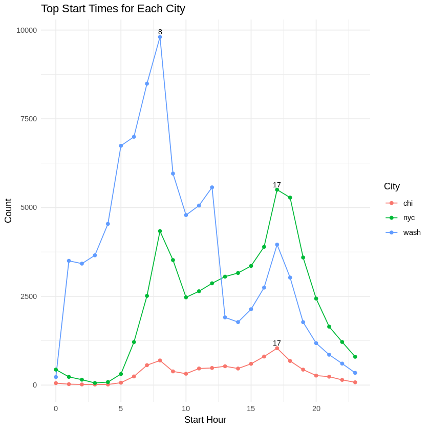

```r
#referenced: https://r-graph-gallery.com/line-plot.html
# Plot the top start times for each city on a single bar plot
ggplot(top_start_times, aes(x = start.hour, y = n, color = City, group = City)) +
  geom_line() +
  geom_point() +
  geom_text(data = most_common_start_hour, aes(label = start.hour),
            vjust = -0.5, color = "black", size = 3) +
  labs(title = "Top Start Times for Each City",
       x = "Start Hour",
       y = "Count",
       color = "City") +
  theme_minimal()
```

```r
#create new column called end.hour

create_end_hour_column <- function(data) {
  data %>%
    mutate(End.Time = ymd_hms(End.Time),
           stop.hour = hour(End.Time))
}

wash <- create_end_hour_column(wash)
ny <- create_end_hour_column(ny)
chi <- create_end_hour_column(chi)

wash
```

| X | Start.Time | End.Time | Trip.Duration | Start.Station | End.Station | User.Type | City | Start.Day | start.hour | stop.hour |
| --- | --- | --- | --- | --- | --- | --- | --- | --- | --- | --- |
| 1621326 | 2017-06-21 08:36:34 | 2017-06-21 08:44:43 | 489.066 | 14th & Belmont St NW | 15th & K St NW | Subscriber | wash | Wednesday | 8 | 8 |
| 482740 | 2017-03-11 10:40:00 | 2017-03-11 10:46:00 | 402.549 | Yuma St & Tenley Circle NW | Connecticut Ave & Yuma St NW | Subscriber | wash | Saturday | 10 | 10 |
| 1330037 | 2017-05-30 01:02:59 | 2017-05-30 01:13:37 | 637.251 | 17th St & Massachusetts Ave NW | 5th & K St NW | Subscriber | wash | Tuesday | 1 | 1 |
| 665458 | 2017-04-02 07:48:35 | 2017-04-02 08:19:03 | 1827.341 | Constitution Ave & 2nd St NW/DOL | M St & Pennsylvania Ave NW | Customer | wash | Sunday | 7 | 8 |
| 1481135 | 2017-06-10 08:36:28 | 2017-06-10 09:02:17 | 1549.427 | Henry Bacon Dr & Lincoln Memorial Circle NW | Maine Ave & 7th St SW | Subscriber | wash | Saturday | 8 | 9 |
| 1148202 | 2017-05-14 07:18:18 | 2017-05-14 07:24:56 | 398.000 | 1st & K St SE | Eastern Market Metro / Pennsylvania Ave & 7th St SE | Subscriber | wash | Sunday | 7 | 7 |
| 1594275 | 2017-06-19 08:41:43 | 2017-06-19 09:00:08 | 1105.429 | Park Rd & Holmead Pl NW | 8th & H St NW | Subscriber | wash | Monday | 8 | 9 |
| 1601832 | 2017-06-20 05:54:42 | 2017-06-20 06:05:18 | 636.218 | 1st & D St SE | Potomac & Pennsylvania Ave SE | Subscriber | wash | Tuesday | 5 | 6 |
| 574182 | 2017-03-24 20:37:00 | 2017-03-24 20:42:00 | 328.530 | 18th & R St NW | 15th & P St NW | Subscriber | wash | Friday | 20 | 20 |
| 327058 | 2017-02-20 21:12:00 | 2017-02-20 21:31:00 | 1188.090 | 17th & Corcoran St NW | Lynn & 19th St North | Subscriber | wash | Monday | 21 | 21 |
| 854729 | 2017-04-17 02:50:51 | 2017-04-17 03:05:17 | 866.689 | 37th & O St NW / Georgetown University | 37th & O St NW / Georgetown University | Customer | wash | Monday | 2 | 3 |
| 721887 | 2017-04-08 01:12:48 | 2017-04-08 01:52:33 | 2385.411 | 10th & G St NW | 5th St & Massachusetts Ave NW | Customer | wash | Saturday | 1 | 1 |
| 143181 | 2017-01-26 20:01:00 | 2017-01-26 20:17:00 | 951.457 | 10th St & L'Enfant Plaza SW | 1st & Rhode Island Ave NW | Subscriber | wash | Thursday | 20 | 20 |
| 26953 | 2017-01-06 17:36:00 | 2017-01-06 17:43:00 | 448.628 | North Capitol St & F St NW | 1st & M St NE | Subscriber | wash | Friday | 17 | 17 |
| 1308542 | 2017-05-28 03:50:26 | 2017-05-28 04:24:26 | 2039.472 | Henry Bacon Dr & Lincoln Memorial Circle NW | Lincoln Memorial | Customer | wash | Sunday | 3 | 4 |
| 1592744 | 2017-06-19 07:46:35 | 2017-06-19 07:55:00 | 505.482 | Metro Center / 12th & G St NW | North Capitol St & G Pl NE | Subscriber | wash | Monday | 7 | 7 |
| 1139713 | 2017-05-13 11:29:16 | 2017-05-13 11:55:47 | 1591.326 | 16th & Harvard St NW | New York Ave & 15th St NW | Customer | wash | Saturday | 11 | 11 |
| 1478516 | 2017-06-10 06:04:41 | 2017-06-10 06:32:33 | 1672.075 | 17th St & Massachusetts Ave NW | 15th & East Capitol St NE | Subscriber | wash | Saturday | 6 | 6 |
| 679837 | 2017-04-03 10:22:19 | 2017-04-03 10:26:11 | 231.952 | 20th & Crystal Dr | 6th & S Ball St | Subscriber | wash | Monday | 10 | 10 |
| 1392498 | 2017-06-03 11:42:54 | 2017-06-03 12:21:05 | 2291.454 | 22nd & I St NW / Foggy Bottom | Lamont & Mt Pleasant NW | Customer | wash | Saturday | 11 | 12 |
| 746605 | 2017-04-09 11:05:42 | 2017-04-09 11:26:44 | 1261.363 | Henry Bacon Dr & Lincoln Memorial Circle NW | Smithsonian-National Mall / Jefferson Dr & 12th St SW | Customer | wash | Sunday | 11 | 11 |
| 868881 | 2017-04-18 05:42:04 | 2017-04-18 06:31:28 | 2964.818 | Anacostia Metro | Congress Heights Metro | Subscriber | wash | Tuesday | 5 | 6 |
| 1161275 | 2017-05-15 07:35:21 | 2017-05-15 07:49:06 | 825.590 | 3rd & H St NE | Oklahoma Ave & D St NE | Subscriber | wash | Monday | 7 | 7 |
| 305000 | 2017-02-19 00:43:00 | 2017-02-19 00:46:00 | 226.006 | 18th St & Wyoming Ave NW | Calvert St & Woodley Pl NW | Subscriber | wash | Sunday | 0 | 0 |
| 1174029 | 2017-05-16 07:34:43 | 2017-05-16 07:50:04 | 920.840 | Florida Ave & R St NW | L'Enfant Plaza / 7th & C St SW | Subscriber | wash | Tuesday | 7 | 7 |
| 1157984 | 2017-05-15 05:39:22 | 2017-05-15 06:02:14 | 1371.512 | Lincoln Memorial | Arlington Blvd & Fillmore St | Subscriber | wash | Monday | 5 | 6 |
| 694527 | 2017-04-05 01:36:31 | 2017-04-05 01:40:45 | 254.076 | 13th St & New York Ave NW | 11th & M St NW | Subscriber | wash | Wednesday | 1 | 1 |
| 228536 | 2017-02-08 09:17:00 | 2017-02-08 09:31:00 | 834.780 | 39th & Calvert St NW / Stoddert | Massachusetts Ave & Dupont Circle NW | Subscriber | wash | Wednesday | 9 | 9 |
| 669432 | 2017-04-02 12:11:35 | 2017-04-02 02:15:22 | 7427.749 | 2nd St & Massachusetts Ave NE | 2nd St & Massachusetts Ave NE | Customer | wash | Sunday | 12 | 2 |
| 1036255 | 2017-05-02 11:49:43 | 2017-05-02 12:09:09 | 1165.698 | 10th & K St NW | Georgetown Harbor / 30th St NW | Subscriber | wash | Tuesday | 11 | 12 |
| ⋮ | ⋮ | ⋮ | ⋮ | ⋮ | ⋮ | ⋮ | ⋮ | ⋮ | ⋮ | ⋮ |
| 676408 | 2017-04-03 07:03:02 | 2017-04-03 07:16:01 | 779.371 | 10th & K St NW | 17th & Corcoran St NW | Subscriber | wash | Monday | 7 | 7 |
| 551347 | 2017-03-22 09:30:00 | 2017-03-22 09:34:00 | 275.761 | Offutt Ln & Chevy Chase Dr | Bethesda Ave & Arlington Rd | Subscriber | wash | Wednesday | 9 | 9 |
| 905153 | 2017-04-21 04:39:43 | 2017-04-21 04:47:19 | 456.235 | 3rd & G St SE | Columbus Circle / Union Station | Subscriber | wash | Friday | 4 | 4 |
| 625949 | 2017-03-29 15:39:00 | 2017-03-29 16:23:00 | 2692.475 | Columbus Circle / Union Station | Washington & Independence Ave SW/HHS | Subscriber | wash | Wednesday | 15 | 16 |
| 1667242 | 2017-06-25 02:03:23 | 2017-06-25 02:07:28 | 244.334 | 13th St & New York Ave NW | 11th & M St NW | Subscriber | wash | Sunday | 2 | 2 |
| 241483 | 2017-02-09 21:14:00 | 2017-02-09 21:22:00 | 468.211 | Braddock Rd Metro | Mount Vernon Ave & E Del Ray Ave | Subscriber | wash | Thursday | 21 | 21 |
| 893870 | 2017-04-20 05:32:02 | 2017-04-20 05:41:26 | 564.069 | 1st & O St NW | 8th & H St NW | Subscriber | wash | Thursday | 5 | 5 |
| 1673660 | 2017-06-25 07:58:00 | 2017-06-25 08:40:40 | 2560.164 | Ballston Metro / N Stuart & 9th St N | Ballston Metro / N Stuart & 9th St N | Subscriber | wash | Sunday | 7 | 8 |
| 531841 | 2017-03-20 11:44:00 | 2017-03-20 11:56:00 | 707.024 | 18th & M St NW | Metro Center / 12th & G St NW | Subscriber | wash | Monday | 11 | 11 |
| 1143611 | 2017-05-14 03:06:09 | 2017-05-14 03:39:27 | 1997.738 | 4th & C St SW | 4th & M St SW | Customer | wash | Sunday | 3 | 3 |
| 760548 | 2017-04-10 09:49:09 | 2017-04-10 10:08:06 | 1136.869 | Jefferson Dr & 14th St SW | 4th St & Madison Dr NW | Customer | wash | Monday | 9 | 10 |
| 585303 | 2017-03-25 16:15:00 | 2017-03-25 17:02:00 | 2817.361 | Jefferson Dr & 14th St SW | New York Ave & 15th St NW | Subscriber | wash | Saturday | 16 | 17 |
| 774610 | 2017-04-11 09:01:58 | 2017-04-11 09:10:36 | 518.196 | 7th & E St SW | 6th St & Indiana Ave NW | Subscriber | wash | Tuesday | 9 | 9 |
| 1681261 | 2017-06-26 03:39:32 | 2017-06-26 03:53:08 | 815.682 | 4th & East Capitol St NE | 4th St & Madison Dr NW | Customer | wash | Monday | 3 | 3 |
| 1068808 | 2017-05-05 12:32:12 | 2017-05-05 12:38:13 | 360.841 | Good Hope Rd & MLK Ave SE | Anacostia Metro | Subscriber | wash | Friday | 12 | 12 |
| 385427 | 2017-02-27 07:03:00 | 2017-02-27 07:12:00 | 543.352 | Alabama & MLK Ave SE | Anacostia Metro | Subscriber | wash | Monday | 7 | 7 |
| 242173 | 2017-02-10 07:39:00 | 2017-02-10 07:48:00 | 577.966 | 20th St & Florida Ave NW | New Hampshire Ave & 24th St NW | Subscriber | wash | Friday | 7 | 7 |
| 982818 | 2017-04-28 11:03:05 | 2017-04-28 11:26:11 | 1385.731 | Lincoln Memorial | Ohio Dr & West Basin Dr SW / MLK & FDR Memorials | Customer | wash | Friday | 11 | 11 |
| 1742606 | 2017-06-30 05:59:23 | 2017-06-30 06:20:17 | 1253.775 | Lincoln Memorial | 17th & G St NW | Customer | wash | Friday | 5 | 6 |
| 1583466 | 2017-06-18 08:44:33 | 2017-06-18 08:51:31 | 417.479 | Maine Ave & 7th St SW | 1st & K St SE | Subscriber | wash | Sunday | 8 | 8 |
| 1500573 | 2017-06-12 03:36:53 | 2017-06-12 03:55:17 | 1104.388 | 5th & F St NW | 10th & G St NW | Subscriber | wash | Monday | 3 | 3 |
| 45867 | 2017-01-11 13:50:00 | 2017-01-11 14:14:00 | 1474.546 | USDA / 12th & Independence Ave SW | Jefferson Memorial | Subscriber | wash | Wednesday | 13 | 14 |
| 1534964 | 2017-06-14 09:33:25 | 2017-06-14 09:49:43 | 978.056 | 10th & K St NW | 8th & East Capitol St NE | Subscriber | wash | Wednesday | 9 | 9 |
| 1371409 | 2017-06-02 06:02:14 | 2017-06-02 06:14:27 | 732.245 | Columbus Circle / Union Station | L'Enfant Plaza / 7th & C St SW | Customer | wash | Friday | 6 | 6 |
| 1484340 | 2017-06-10 10:58:09 | 2017-06-10 11:25:58 | 1669.700 | M St & New Jersey Ave SE | 4th St & Madison Dr NW | Customer | wash | Saturday | 10 | 11 |
| 555788 | 2017-03-22 18:46:00 | 2017-03-22 19:04:00 | 1082.789 | 8th & H St NW | 21st & I St NW | Subscriber | wash | Wednesday | 18 | 19 |
| 739004 | 2017-04-09 04:00:22 | 2017-04-09 04:09:54 | 571.879 | Eckington Pl & Q St NE | Columbus Circle / Union Station | Subscriber | wash | Sunday | 4 | 4 |
| 1214907 | 2017-05-19 09:00:53 | 2017-05-19 09:07:38 | 404.152 | 1st & M St NE | 1st & Rhode Island Ave NW | Subscriber | wash | Friday | 9 | 9 |
| 1419806 | 2017-06-06 04:27:33 | 2017-06-06 04:49:59 | 1345.911 | 10th & Florida Ave NW | Georgetown Harbor / 30th St NW | Customer | wash | Tuesday | 4 | 4 |
| 132 | NA | NA | NA |  |  |  | wash | NA | NA | NA |

```r
#creating a new merged dataframe to work with
stop_hr_merge <- rbind(chi, ny)
stop_hr_merge


#need to drop the gender and birth year columns to merge with wash
stop_hr_merge <- stop_hr_merge %>%
  select(-c("Gender", "Birth.Year"))


#complete the merge
stop_hr_merge <- rbind(stop_hr_merge, wash)

stop_hr_merge
```

| X | Start.Time | End.Time | Trip.Duration | Start.Station | End.Station | User.Type | Gender | Birth.Year | City | Start.Day | start.hour | stop.hour |
| --- | --- | --- | --- | --- | --- | --- | --- | --- | --- | --- | --- | --- |
| 1423854 | 2017-06-23 15:09:32 | 2017-06-23 15:14:53 | 321 | Wood St & Hubbard St | Damen Ave & Chicago Ave | Subscriber | Male | 1992 | chi | Friday | 15 | 15 |
| 955915 | 2017-05-25 18:19:03 | 2017-05-25 18:45:53 | 1610 | Theater on the Lake | Sheffield Ave & Waveland Ave | Subscriber | Female | 1992 | chi | Thursday | 18 | 18 |
| 9031 | 2017-01-04 08:27:49 | 2017-01-04 08:34:45 | 416 | May St & Taylor St | Wood St & Taylor St | Subscriber | Male | 1981 | chi | Wednesday | 8 | 8 |
| 304487 | 2017-03-06 13:49:38 | 2017-03-06 13:55:28 | 350 | Christiana Ave & Lawrence Ave | St. Louis Ave & Balmoral Ave | Subscriber | Male | 1986 | chi | Monday | 13 | 13 |
| 45207 | 2017-01-17 14:53:07 | 2017-01-17 15:02:01 | 534 | Clark St & Randolph St | Desplaines St & Jackson Blvd | Subscriber | Male | 1975 | chi | Tuesday | 14 | 15 |
| 1473887 | 2017-06-26 09:01:20 | 2017-06-26 09:11:06 | 586 | Clinton St & Washington Blvd | Canal St & Taylor St | Subscriber | Male | 1990 | chi | Monday | 9 | 9 |
| 961916 | 2017-05-26 09:41:44 | 2017-05-26 09:46:25 | 281 | Ashland Ave & Lake St | Wood St & Hubbard St | Subscriber | Female | 1983 | chi | Friday | 9 | 9 |
| 65924 | 2017-01-21 14:28:38 | 2017-01-21 14:40:41 | 723 | Larrabee St & Kingsbury St | Larrabee St & Armitage Ave | Customer |  | NA | chi | Saturday | 14 | 14 |
| 606841 | 2017-04-20 16:08:51 | 2017-04-20 16:20:20 | 689 | Sedgwick St & Huron St | Halsted St & Blackhawk St (*) | Subscriber | Male | 1984 | chi | Thursday | 16 | 16 |
| 135470 | 2017-02-06 18:00:47 | 2017-02-06 18:09:00 | 493 | Stetson Ave & South Water St | Clinton St & Washington Blvd | Subscriber | Male | 1979 | chi | Monday | 18 | 18 |
| 175805 | 2017-02-15 07:09:55 | 2017-02-15 07:14:56 | 301 | Broadway & Barry Ave | Wilton Ave & Belmont Ave | Subscriber | Female | 1993 | chi | Wednesday | 7 | 7 |
| 71678 | 2017-01-22 15:15:45 | 2017-01-22 15:31:02 | 917 | Southport Ave & Wellington Ave | Clark St & Schiller St | Subscriber | Male | 1964 | chi | Sunday | 15 | 15 |
| 19061 | 2017-01-08 16:03:00 | 2017-01-08 16:07:37 | 277 | Green St & Madison St | Ada St & Washington Blvd | Subscriber | Male | 1961 | chi | Sunday | 16 | 16 |
| 1023296 | 2017-05-30 15:46:18 | 2017-05-30 15:52:12 | 354 | Larrabee St & Kingsbury St | Clark St & Elm St | Subscriber | Male | 1985 | chi | Tuesday | 15 | 15 |
| 611000 | 2017-04-20 19:26:33 | 2017-04-20 19:35:08 | 515 | Canal St & Madison St | Racine Ave (May St) & Fulton St | Subscriber | Male | 1984 | chi | Thursday | 19 | 19 |
| 958716 | 2017-05-25 22:59:33 | 2017-05-25 23:07:19 | 466 | Clark St & Armitage Ave | Sheffield Ave & Wrightwood Ave | Subscriber | Female | 1985 | chi | Thursday | 22 | 23 |
| 718598 | 2017-05-03 13:20:38 | 2017-05-03 13:31:13 | 635 | Ada St & Washington Blvd | Daley Center Plaza | Subscriber | Male | 1967 | chi | Wednesday | 13 | 13 |
| 931608 | 2017-05-23 08:08:25 | 2017-05-23 08:11:09 | 164 | Damen Ave & Cortland St | Marshfield Ave & Cortland St | Subscriber | Male | 1990 | chi | Tuesday | 8 | 8 |
| 1469705 | 2017-06-25 21:26:30 | 2017-06-25 21:33:44 | 434 | State St & Pearson St | Clark St & Schiller St | Subscriber | Male | 1987 | chi | Sunday | 21 | 21 |
| 475456 | 2017-04-08 11:37:55 | 2017-04-08 11:51:55 | 840 | Adler Planetarium | Burnham Harbor | Customer |  | NA | chi | Saturday | 11 | 11 |
| 849468 | 2017-05-16 06:36:17 | 2017-05-16 06:59:34 | 1397 | Michigan Ave & Oak St | Halsted St & Wrightwood Ave | Subscriber | Female | 1992 | chi | Tuesday | 6 | 6 |
| 1420915 | 2017-06-23 12:21:01 | 2017-06-23 12:32:54 | 713 | Rush St & Cedar St | Halsted St & Willow St | Subscriber | Male | 1985 | chi | Friday | 12 | 12 |
| 161454 | 2017-02-12 15:24:29 | 2017-02-12 15:38:43 | 854 | Clarendon Ave & Leland Ave | Lake Shore Dr & Belmont Ave | Subscriber | Male | 1980 | chi | Sunday | 15 | 15 |
| 1413814 | 2017-06-22 19:14:37 | 2017-06-22 19:29:54 | 917 | Bissell St & Armitage Ave | Orleans St & Chestnut St (NEXT Apts) | Subscriber | Female | 1989 | chi | Thursday | 19 | 19 |
| 717248 | 2017-05-03 09:41:11 | 2017-05-03 09:49:10 | 479 | Wabash Ave & Roosevelt Rd | Halsted St & Roosevelt Rd | Subscriber | Male | 1992 | chi | Wednesday | 9 | 9 |
| 1451810 | 2017-06-24 20:47:40 | 2017-06-24 21:13:39 | 1559 | Rush St & Cedar St | Halsted St & Roscoe St | Subscriber | Male | 1968 | chi | Saturday | 20 | 21 |
| 385517 | 2017-03-23 09:38:27 | 2017-03-23 09:42:41 | 254 | Loomis St & Jackson Blvd | Peoria St & Jackson Blvd | Subscriber | Female | 1985 | chi | Thursday | 9 | 9 |
| 1186035 | 2017-06-09 07:48:55 | 2017-06-09 07:52:30 | 215 | Canal St & Madison St | Clark St & Randolph St | Subscriber | Male | 1974 | chi | Friday | 7 | 7 |
| 512692 | 2017-04-11 18:49:57 | 2017-04-11 18:59:36 | 579 | Clinton St & Lake St | Mies van der Rohe Way & Chestnut St | Subscriber | Male | 1989 | chi | Tuesday | 18 | 18 |
| 261757 | 2017-02-25 19:01:19 | 2017-02-25 19:08:10 | 411 | Halsted St & Dickens Ave | Halsted St & Wrightwood Ave | Subscriber | Male | 1970 | chi | Saturday | 19 | 19 |
| ⋮ | ⋮ | ⋮ | ⋮ | ⋮ | ⋮ | ⋮ | ⋮ | ⋮ | ⋮ | ⋮ | ⋮ | ⋮ |
| 4203558 | 2017-05-14 13:58:01 | 2017-05-14 14:39:38 | 2496 | S 3 St & Bedford Ave | 3 St & Prospect Park West | Subscriber | Male | 1985 | nyc | Sunday | 13 | 14 |
| 5352804 | 2017-06-05 17:44:35 | 2017-06-05 17:48:44 | 249 | Vesey Pl & River Terrace | Greenwich St & Hubert St | Subscriber | Male | 1968 | nyc | Monday | 17 | 17 |
| 3532080 | 2017-04-30 12:22:15 | 2017-04-30 12:45:56 | 1420 | Barrow St & Hudson St | Little West St & 1 Pl | Subscriber | Male | 1957 | nyc | Sunday | 12 | 12 |
| 2935863 | 2017-04-17 11:50:15 | 2017-04-17 11:59:08 | 533 | 9 Ave & W 28 St | W 15 St & 7 Ave | Subscriber | Male | 1950 | nyc | Monday | 11 | 11 |
| 6156169 | 2017-06-20 11:06:16 | 2017-06-20 11:12:40 | 383 | 9 Ave & W 18 St | W 21 St & 6 Ave | Subscriber | Male | 1987 | nyc | Tuesday | 11 | 11 |
| 250989 | 2017-01-13 07:37:50 | 2017-01-13 07:44:16 | 386 | Maiden Ln & Pearl St | Centre St & Worth St | Subscriber | Male | 1958 | nyc | Friday | 7 | 7 |
| 1275463 | 2017-02-22 16:00:25 | 2017-02-22 16:05:41 | 315 | Greenwich St & Hubert St | Vesey Pl & River Terrace | Subscriber | Male | 1981 | nyc | Wednesday | 16 | 16 |
| 3161273 | 2017-04-22 10:03:26 | 2017-04-22 10:07:12 | 226 | E 10 St & Avenue A | E 3 St & 1 Ave | Subscriber | Male | 1960 | nyc | Saturday | 10 | 10 |
| 4211314 | 2017-05-14 16:18:42 | 2017-05-14 16:35:23 | 1001 | Scholes St & Manhattan Ave | S 3 St & Bedford Ave | Subscriber | Female | 1991 | nyc | Sunday | 16 | 16 |
| 1717314 | 2017-03-07 21:15:14 | 2017-03-07 21:26:37 | 682 | Lexington Ave & E 24 St | Greenwich Ave & 8 Ave | Subscriber | Female | 1980 | nyc | Tuesday | 21 | 21 |
| 1881529 | 2017-03-13 21:21:15 | 2017-03-13 21:37:33 | 978 | 1 Ave & E 16 St | Canal St & Rutgers St | Subscriber | Female | 1990 | nyc | Monday | 21 | 21 |
| 1047928 | 2017-02-15 13:40:07 | 2017-02-15 13:47:07 | 420 | E 30 St & Park Ave S | W 33 St & 7 Ave | Subscriber | Male | 1990 | nyc | Wednesday | 13 | 13 |
| 5623210 | 2017-06-10 12:31:08 | 2017-06-10 12:56:57 | 1549 | West End Ave & W 94 St | 12 Ave & W 40 St | Subscriber | Male | 1978 | nyc | Saturday | 12 | 12 |
| 3197884 | 2017-04-23 10:54:11 | 2017-04-23 10:59:17 | 306 | W 20 St & 8 Ave | Broadway & E 22 St | Subscriber | Male | 1974 | nyc | Sunday | 10 | 10 |
| 5758780 | 2017-06-12 18:45:44 | 2017-06-12 19:12:48 | 1623 | W 16 St & The High Line | W 16 St & The High Line | Subscriber | Female | 1981 | nyc | Monday | 18 | 19 |
| 5082390 | 2017-05-31 22:00:22 | 2017-05-31 22:04:03 | 221 | Sullivan St & Washington Sq | Great Jones St | Subscriber | Male | 1991 | nyc | Wednesday | 22 | 22 |
| 2521938 | 2017-04-09 07:34:19 | 2017-04-09 07:54:57 | 1238 | 5 Ave & E 88 St | Amsterdam Ave & W 79 St | Subscriber | Male | 1978 | nyc | Sunday | 7 | 7 |
| 3759176 | 2017-05-04 12:03:54 | 2017-05-04 12:14:50 | 655 | Broadway & W 36 St | E 17 St & Broadway | Subscriber | Female | 1964 | nyc | Thursday | 12 | 12 |
| 246004 | 2017-01-12 21:42:18 | 2017-01-12 21:51:14 | 536 | Pier 40 - Hudson River Park | Franklin St & W Broadway | Subscriber | Male | 1965 | nyc | Thursday | 21 | 21 |
| 1951636 | 2017-03-21 16:27:03 | 2017-03-21 16:41:04 | 841 | 6 Ave & Canal St | W 31 St & 7 Ave | Subscriber | Male | 1976 | nyc | Tuesday | 16 | 16 |
| 6227477 | 2017-06-21 12:44:04 | 2017-06-21 13:09:09 | 1505 | W 49 St & 8 Ave | South End Ave & Liberty St | Subscriber | Male | 1982 | nyc | Wednesday | 12 | 13 |
| 6309606 | 2017-06-22 17:09:31 | 2017-06-22 17:18:06 | 514 | Barclay St & Church St | South End Ave & Liberty St | Subscriber | Male | 1976 | nyc | Thursday | 17 | 17 |
| 5532367 | 2017-06-08 19:59:16 | 2017-06-08 20:06:48 | 451 | Broadway & E 22 St | E 12 St & 3 Ave | Subscriber | Male | 1982 | nyc | Thursday | 19 | 20 |
| 5517974 | 2017-06-08 17:29:01 | 2017-06-08 17:35:50 | 408 | Broadway & W 41 St | W 47 St & 10 Ave | Subscriber | Male | 1980 | nyc | Thursday | 17 | 17 |
| 1293888 | 2017-02-23 06:14:14 | 2017-02-23 06:23:32 | 558 | E 27 St & 1 Ave | E 47 St & Park Ave | Subscriber | Male | 1984 | nyc | Thursday | 6 | 6 |
| 642855 | 2017-01-28 16:44:18 | 2017-01-28 16:48:18 | 240 | W 52 St & 9 Ave | 9 Ave & W 45 St | Subscriber | Male | 1991 | nyc | Saturday | 16 | 16 |
| 2157959 | 2017-03-29 06:30:35 | 2017-03-29 06:32:41 | 125 | W 84 St & Columbus Ave | W 87 St & Amsterdam Ave | Subscriber | Male | 1984 | nyc | Wednesday | 6 | 6 |
| 5679624 | 2017-06-11 12:52:27 | 2017-06-11 12:58:35 | 367 | 8 Ave & W 33 St | W 45 St & 8 Ave | Subscriber | Male | 1954 | nyc | Sunday | 12 | 12 |
| 6762960 | 2017-06-30 07:48:34 | 2017-06-30 08:17:16 | 1722 | Cathedral Pkwy & Broadway | Broadway & W 51 St | Subscriber | Male | 1974 | nyc | Friday | 7 | 8 |
| 6078570 | 2017-06-18 16:20:21 | NA | NA |  |  |  |  | NA | nyc | Sunday | 16 | NA |

| X | Start.Time | End.Time | Trip.Duration | Start.Station | End.Station | User.Type | City | Start.Day | start.hour | stop.hour |
| --- | --- | --- | --- | --- | --- | --- | --- | --- | --- | --- |
| 1423854 | 2017-06-23 15:09:32 | 2017-06-23 15:14:53 | 321 | Wood St & Hubbard St | Damen Ave & Chicago Ave | Subscriber | chi | Friday | 15 | 15 |
| 955915 | 2017-05-25 18:19:03 | 2017-05-25 18:45:53 | 1610 | Theater on the Lake | Sheffield Ave & Waveland Ave | Subscriber | chi | Thursday | 18 | 18 |
| 9031 | 2017-01-04 08:27:49 | 2017-01-04 08:34:45 | 416 | May St & Taylor St | Wood St & Taylor St | Subscriber | chi | Wednesday | 8 | 8 |
| 304487 | 2017-03-06 13:49:38 | 2017-03-06 13:55:28 | 350 | Christiana Ave & Lawrence Ave | St. Louis Ave & Balmoral Ave | Subscriber | chi | Monday | 13 | 13 |
| 45207 | 2017-01-17 14:53:07 | 2017-01-17 15:02:01 | 534 | Clark St & Randolph St | Desplaines St & Jackson Blvd | Subscriber | chi | Tuesday | 14 | 15 |
| 1473887 | 2017-06-26 09:01:20 | 2017-06-26 09:11:06 | 586 | Clinton St & Washington Blvd | Canal St & Taylor St | Subscriber | chi | Monday | 9 | 9 |
| 961916 | 2017-05-26 09:41:44 | 2017-05-26 09:46:25 | 281 | Ashland Ave & Lake St | Wood St & Hubbard St | Subscriber | chi | Friday | 9 | 9 |
| 65924 | 2017-01-21 14:28:38 | 2017-01-21 14:40:41 | 723 | Larrabee St & Kingsbury St | Larrabee St & Armitage Ave | Customer | chi | Saturday | 14 | 14 |
| 606841 | 2017-04-20 16:08:51 | 2017-04-20 16:20:20 | 689 | Sedgwick St & Huron St | Halsted St & Blackhawk St (*) | Subscriber | chi | Thursday | 16 | 16 |
| 135470 | 2017-02-06 18:00:47 | 2017-02-06 18:09:00 | 493 | Stetson Ave & South Water St | Clinton St & Washington Blvd | Subscriber | chi | Monday | 18 | 18 |
| 175805 | 2017-02-15 07:09:55 | 2017-02-15 07:14:56 | 301 | Broadway & Barry Ave | Wilton Ave & Belmont Ave | Subscriber | chi | Wednesday | 7 | 7 |
| 71678 | 2017-01-22 15:15:45 | 2017-01-22 15:31:02 | 917 | Southport Ave & Wellington Ave | Clark St & Schiller St | Subscriber | chi | Sunday | 15 | 15 |
| 19061 | 2017-01-08 16:03:00 | 2017-01-08 16:07:37 | 277 | Green St & Madison St | Ada St & Washington Blvd | Subscriber | chi | Sunday | 16 | 16 |
| 1023296 | 2017-05-30 15:46:18 | 2017-05-30 15:52:12 | 354 | Larrabee St & Kingsbury St | Clark St & Elm St | Subscriber | chi | Tuesday | 15 | 15 |
| 611000 | 2017-04-20 19:26:33 | 2017-04-20 19:35:08 | 515 | Canal St & Madison St | Racine Ave (May St) & Fulton St | Subscriber | chi | Thursday | 19 | 19 |
| 958716 | 2017-05-25 22:59:33 | 2017-05-25 23:07:19 | 466 | Clark St & Armitage Ave | Sheffield Ave & Wrightwood Ave | Subscriber | chi | Thursday | 22 | 23 |
| 718598 | 2017-05-03 13:20:38 | 2017-05-03 13:31:13 | 635 | Ada St & Washington Blvd | Daley Center Plaza | Subscriber | chi | Wednesday | 13 | 13 |
| 931608 | 2017-05-23 08:08:25 | 2017-05-23 08:11:09 | 164 | Damen Ave & Cortland St | Marshfield Ave & Cortland St | Subscriber | chi | Tuesday | 8 | 8 |
| 1469705 | 2017-06-25 21:26:30 | 2017-06-25 21:33:44 | 434 | State St & Pearson St | Clark St & Schiller St | Subscriber | chi | Sunday | 21 | 21 |
| 475456 | 2017-04-08 11:37:55 | 2017-04-08 11:51:55 | 840 | Adler Planetarium | Burnham Harbor | Customer | chi | Saturday | 11 | 11 |
| 849468 | 2017-05-16 06:36:17 | 2017-05-16 06:59:34 | 1397 | Michigan Ave & Oak St | Halsted St & Wrightwood Ave | Subscriber | chi | Tuesday | 6 | 6 |
| 1420915 | 2017-06-23 12:21:01 | 2017-06-23 12:32:54 | 713 | Rush St & Cedar St | Halsted St & Willow St | Subscriber | chi | Friday | 12 | 12 |
| 161454 | 2017-02-12 15:24:29 | 2017-02-12 15:38:43 | 854 | Clarendon Ave & Leland Ave | Lake Shore Dr & Belmont Ave | Subscriber | chi | Sunday | 15 | 15 |
| 1413814 | 2017-06-22 19:14:37 | 2017-06-22 19:29:54 | 917 | Bissell St & Armitage Ave | Orleans St & Chestnut St (NEXT Apts) | Subscriber | chi | Thursday | 19 | 19 |
| 717248 | 2017-05-03 09:41:11 | 2017-05-03 09:49:10 | 479 | Wabash Ave & Roosevelt Rd | Halsted St & Roosevelt Rd | Subscriber | chi | Wednesday | 9 | 9 |
| 1451810 | 2017-06-24 20:47:40 | 2017-06-24 21:13:39 | 1559 | Rush St & Cedar St | Halsted St & Roscoe St | Subscriber | chi | Saturday | 20 | 21 |
| 385517 | 2017-03-23 09:38:27 | 2017-03-23 09:42:41 | 254 | Loomis St & Jackson Blvd | Peoria St & Jackson Blvd | Subscriber | chi | Thursday | 9 | 9 |
| 1186035 | 2017-06-09 07:48:55 | 2017-06-09 07:52:30 | 215 | Canal St & Madison St | Clark St & Randolph St | Subscriber | chi | Friday | 7 | 7 |
| 512692 | 2017-04-11 18:49:57 | 2017-04-11 18:59:36 | 579 | Clinton St & Lake St | Mies van der Rohe Way & Chestnut St | Subscriber | chi | Tuesday | 18 | 18 |
| 261757 | 2017-02-25 19:01:19 | 2017-02-25 19:08:10 | 411 | Halsted St & Dickens Ave | Halsted St & Wrightwood Ave | Subscriber | chi | Saturday | 19 | 19 |
| ⋮ | ⋮ | ⋮ | ⋮ | ⋮ | ⋮ | ⋮ | ⋮ | ⋮ | ⋮ | ⋮ |
| 676408 | 2017-04-03 07:03:02 | 2017-04-03 07:16:01 | 779.371 | 10th & K St NW | 17th & Corcoran St NW | Subscriber | wash | Monday | 7 | 7 |
| 551347 | 2017-03-22 09:30:00 | 2017-03-22 09:34:00 | 275.761 | Offutt Ln & Chevy Chase Dr | Bethesda Ave & Arlington Rd | Subscriber | wash | Wednesday | 9 | 9 |
| 905153 | 2017-04-21 04:39:43 | 2017-04-21 04:47:19 | 456.235 | 3rd & G St SE | Columbus Circle / Union Station | Subscriber | wash | Friday | 4 | 4 |
| 625949 | 2017-03-29 15:39:00 | 2017-03-29 16:23:00 | 2692.475 | Columbus Circle / Union Station | Washington & Independence Ave SW/HHS | Subscriber | wash | Wednesday | 15 | 16 |
| 1667242 | 2017-06-25 02:03:23 | 2017-06-25 02:07:28 | 244.334 | 13th St & New York Ave NW | 11th & M St NW | Subscriber | wash | Sunday | 2 | 2 |
| 241483 | 2017-02-09 21:14:00 | 2017-02-09 21:22:00 | 468.211 | Braddock Rd Metro | Mount Vernon Ave & E Del Ray Ave | Subscriber | wash | Thursday | 21 | 21 |
| 893870 | 2017-04-20 05:32:02 | 2017-04-20 05:41:26 | 564.069 | 1st & O St NW | 8th & H St NW | Subscriber | wash | Thursday | 5 | 5 |
| 1673660 | 2017-06-25 07:58:00 | 2017-06-25 08:40:40 | 2560.164 | Ballston Metro / N Stuart & 9th St N | Ballston Metro / N Stuart & 9th St N | Subscriber | wash | Sunday | 7 | 8 |
| 531841 | 2017-03-20 11:44:00 | 2017-03-20 11:56:00 | 707.024 | 18th & M St NW | Metro Center / 12th & G St NW | Subscriber | wash | Monday | 11 | 11 |
| 1143611 | 2017-05-14 03:06:09 | 2017-05-14 03:39:27 | 1997.738 | 4th & C St SW | 4th & M St SW | Customer | wash | Sunday | 3 | 3 |
| 760548 | 2017-04-10 09:49:09 | 2017-04-10 10:08:06 | 1136.869 | Jefferson Dr & 14th St SW | 4th St & Madison Dr NW | Customer | wash | Monday | 9 | 10 |
| 585303 | 2017-03-25 16:15:00 | 2017-03-25 17:02:00 | 2817.361 | Jefferson Dr & 14th St SW | New York Ave & 15th St NW | Subscriber | wash | Saturday | 16 | 17 |
| 774610 | 2017-04-11 09:01:58 | 2017-04-11 09:10:36 | 518.196 | 7th & E St SW | 6th St & Indiana Ave NW | Subscriber | wash | Tuesday | 9 | 9 |
| 1681261 | 2017-06-26 03:39:32 | 2017-06-26 03:53:08 | 815.682 | 4th & East Capitol St NE | 4th St & Madison Dr NW | Customer | wash | Monday | 3 | 3 |
| 1068808 | 2017-05-05 12:32:12 | 2017-05-05 12:38:13 | 360.841 | Good Hope Rd & MLK Ave SE | Anacostia Metro | Subscriber | wash | Friday | 12 | 12 |
| 385427 | 2017-02-27 07:03:00 | 2017-02-27 07:12:00 | 543.352 | Alabama & MLK Ave SE | Anacostia Metro | Subscriber | wash | Monday | 7 | 7 |
| 242173 | 2017-02-10 07:39:00 | 2017-02-10 07:48:00 | 577.966 | 20th St & Florida Ave NW | New Hampshire Ave & 24th St NW | Subscriber | wash | Friday | 7 | 7 |
| 982818 | 2017-04-28 11:03:05 | 2017-04-28 11:26:11 | 1385.731 | Lincoln Memorial | Ohio Dr & West Basin Dr SW / MLK & FDR Memorials | Customer | wash | Friday | 11 | 11 |
| 1742606 | 2017-06-30 05:59:23 | 2017-06-30 06:20:17 | 1253.775 | Lincoln Memorial | 17th & G St NW | Customer | wash | Friday | 5 | 6 |
| 1583466 | 2017-06-18 08:44:33 | 2017-06-18 08:51:31 | 417.479 | Maine Ave & 7th St SW | 1st & K St SE | Subscriber | wash | Sunday | 8 | 8 |
| 1500573 | 2017-06-12 03:36:53 | 2017-06-12 03:55:17 | 1104.388 | 5th & F St NW | 10th & G St NW | Subscriber | wash | Monday | 3 | 3 |
| 45867 | 2017-01-11 13:50:00 | 2017-01-11 14:14:00 | 1474.546 | USDA / 12th & Independence Ave SW | Jefferson Memorial | Subscriber | wash | Wednesday | 13 | 14 |
| 1534964 | 2017-06-14 09:33:25 | 2017-06-14 09:49:43 | 978.056 | 10th & K St NW | 8th & East Capitol St NE | Subscriber | wash | Wednesday | 9 | 9 |
| 1371409 | 2017-06-02 06:02:14 | 2017-06-02 06:14:27 | 732.245 | Columbus Circle / Union Station | L'Enfant Plaza / 7th & C St SW | Customer | wash | Friday | 6 | 6 |
| 1484340 | 2017-06-10 10:58:09 | 2017-06-10 11:25:58 | 1669.700 | M St & New Jersey Ave SE | 4th St & Madison Dr NW | Customer | wash | Saturday | 10 | 11 |
| 555788 | 2017-03-22 18:46:00 | 2017-03-22 19:04:00 | 1082.789 | 8th & H St NW | 21st & I St NW | Subscriber | wash | Wednesday | 18 | 19 |
| 739004 | 2017-04-09 04:00:22 | 2017-04-09 04:09:54 | 571.879 | Eckington Pl & Q St NE | Columbus Circle / Union Station | Subscriber | wash | Sunday | 4 | 4 |
| 1214907 | 2017-05-19 09:00:53 | 2017-05-19 09:07:38 | 404.152 | 1st & M St NE | 1st & Rhode Island Ave NW | Subscriber | wash | Friday | 9 | 9 |
| 1419806 | 2017-06-06 04:27:33 | 2017-06-06 04:49:59 | 1345.911 | 10th & Florida Ave NW | Georgetown Harbor / 30th St NW | Customer | wash | Tuesday | 4 | 4 |
| 132 | NA | NA | NA |  |  |  | wash | NA | NA | NA |

```r
#find the top start time for each city in the merged dataframe

top_stop_times <- stop_hr_merge %>%
  group_by(City, stop.hour) %>%
  count() %>%
  na.omit() %>%
  top_n(1, wt = n) %>%
  arrange(City, desc(n))

# Find the most common start hour for each city
most_common_stop_hour <- top_stop_times %>%
  group_by(City) %>%
  filter(n == max(n)) %>%
  distinct(City, .keep_all = TRUE)

most_common_stop_hour
```

| City | stop.hour | n |
| --- | --- | --- |
| chi | 17 | 1075 |
| nyc | 18 | 5544 |
| wash | 8 | 9948 |

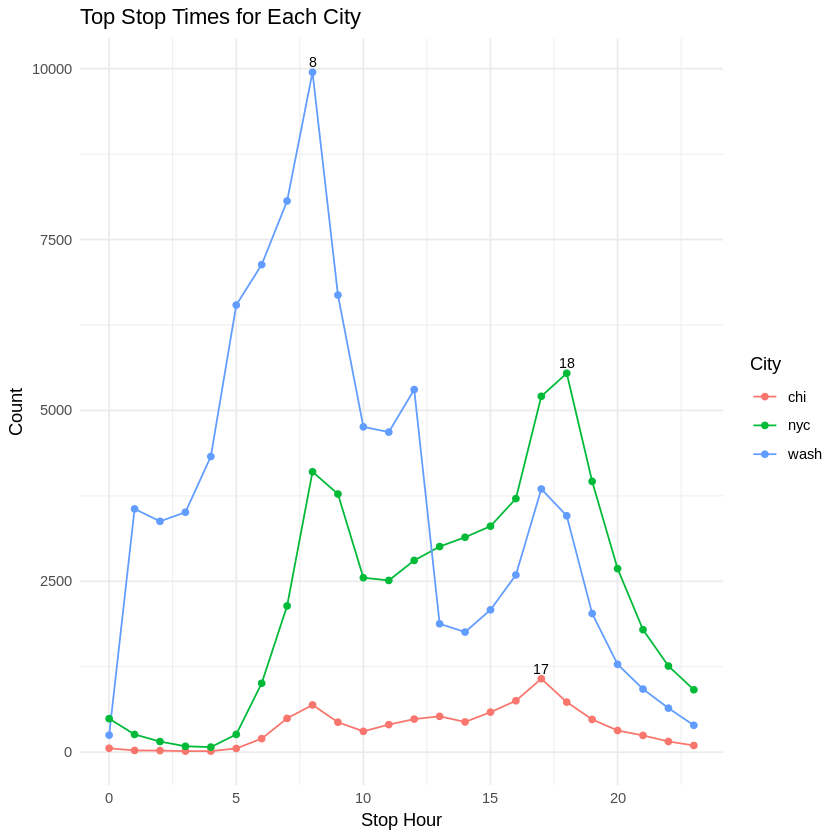

```r
# Plot the top start times for each city on a single bar plot
ggplot(top_stop_times, aes(x = stop.hour, y = n, color = City, group = City)) +
  geom_line() +
  geom_point() +
  geom_text(data = most_common_stop_hour, aes(label = stop.hour),
            vjust = -0.5, color = "black", size = 3) +
  labs(title = "Top Stop Times for Each City",
       x = "Stop Hour",
       y = "Count",
       color = "City") +
  theme_minimal()
```

### Question 3

#### What hour of the day are the most popular to start and stop rides?

###### Washington

> In Washington, the popular starting and stopping hour are both 8am, which indicates the rides may be very short.

###### Chicago

> In Chicago, the popular starting and stopping hour are both 5pm, which could also indicate the rides may be short.

## Finishing Up

> Congratulations! You have reached the end of the Explore Bikeshare Data Project. You should be very proud of all you have accomplished!

> **Tip**: Once you are satisfied with your work here, check over your report to make sure that it is satisfies all the areas of the [rubric](https://review.udacity.com/#!/rubrics/2508/view).

## Directions to Submit

> Before you submit your project, you need to create a .html or .pdf version of this notebook in the workspace here. To do that, run the code cell below. If it worked correctly, you should get a return code of 0, and you should see the generated .html file in the workspace directory (click on the orange Jupyter icon in the upper left).

> Alternatively, you can download this report as .html via the **File** > **Download as** submenu, and then manually upload it into the workspace directory by clicking on the orange Jupyter icon in the upper left, then using the Upload button.

> Once you've done this, you can submit your project by clicking on the "Submit Project" button in the lower right here. This will create and submit a zip file with this .ipynb doc and the .html or .pdf version you created. Congratulations!

```r
system('python -m nbconvert Explore_bikeshare_data.ipynb')
```